# ACTG175 (Continuous): Comparing Selection Rules

effMaxSG with selection_rule ∈ {pareto, both}

**Setup (click to expand)**

```r
# Initialize timing
t_doc_start <- proc.time()
timings <- list()
```

# 1 Introduction

The structure is:

1. **Data setup + ITT** — identical to the single-rule analyses.
2. **Comparison run** — one call to `compare_selection_rules()` that handles the loop, captures each run’s `CANDIDATE EVALUATION PREVIEW` + `CANDIDATE EVALUATION SUMMARY` banners, builds the Pareto-frontier plots, and computes split-derived CIs.
3. **Per-combo diagnostics** — replay of captured console output, individual frontier plot/table/narrative for each combination.
4. **Side-by-side composition** — patchwork-composed plot panel for direct visual comparison.

Bootstrap, cross-validation, and the combined forest plot are **deliberately omitted** so the document stays focused on the *selection mechanism* and the comparison reads as a tight diagnostic of the rule axis alone.

# 2 Setup

## 2.1 Load Required Packages

```r
suppressPackageStartupMessages({
  library(forestsearch)
  library(speff2trial)       # ACTG175 dataset
  library(data.table)
  library(ggplot2)
  library(gt)
  library(future)
  library(patchwork)         # for side-by-side plot composition
})

# Source the comparison wrapper.  When this graduates into the package
# (copy compare_selection_rules.R into R/ and run devtools::document()),
# this source() line can be removed.
#source("compare_selection_rules.R")

# Set ggplot theme
theme_set(theme_minimal(base_size = 12))
```

## 2.2 Analysis Parameters

All ForestSearch parameters are defined here once and reused for both combinations. The two axes of variation are `sg_focus` and `selection_rule`, which the wrapper handles directly.

```r
# ─── Parallel processing ────────────────────────────────────────────────
n_cores <- max(1L, floor(0.95 * parallel::detectCores(logical = FALSE)))

# ─── Reproducibility ────────────────────────────────────────────────────
analysis_seed <- 8316951L
set.seed(analysis_seed)

# ─── Confounders ───────────────────────────────────────────────────────
cont_vars <- c("age", "preanti", "wtkg", "karnof", "cd40", "cd80")
bin_vars  <- c("hemo", "homo", "drugs", "race", "gender", "symptom")
confounders.name <- c(cont_vars, bin_vars)
id.name <- "id"

# ─── Variables (dual-scale framing) ────────────────────────────────────
treat.name         <- "treat"
adverse_outcome    <- "y_decline"   # FS adverse-scale outcome
beneficial_outcome <- "y_improve"   # GRF beneficial-scale outcome

# ─── ForestSearch parameters (continuous, MD scale) ────────────────────
fs_outcome_type    <- "continuous"
fs_effect_measure  <- "MD"

# NOTE: fs_sg_focus and fs_selection_rule are NOT defined here.
# They live in the `comparison-axes` chunk below as the two axes the
# wrapper varies.  All OTHER ForestSearch parameters are fixed across
# the comparison.

# Thresholds in CD4 count units (adverse scale: MD > c1 = harm)
fs_md_threshold    <- 10    # screening: MD >= 10 indicates harm
fs_md_consistency  <- 5     # consistency: MD >= 5

# Identification engine, pinned explicitly.  This document predates the
# default flip in 269dc9aa ("consistency_method defaults to resample"); it was
# written when the default was something else, so leaving it unpinned would
# make the configuration depend on the package version that happens to render
# it.  "resample" is the stated modern configuration and is what the committed
# simulation twin runs.
fs_consistency_method <- "resample"

# Per-variable J-quantile grids on ALL SIX continuous covariates (the survival
# template's `er = 10` pattern, widened).  For an entry X = J the default cut
# set for X is replaced by J binary cut points at the (k/(J+1))-th quantiles,
# k = 1..J.  Rationale: the default cut set is sparse (4 cuts per continuous
# covariate on this data), so the fixed family cannot explore the range of any
# continuous factor; at J = 10 each covariate contributes 10 candidate
# thresholds spanning its distribution.
# NOTE this REPLACES the previous list(cd40 = 10, wtkg = 10) at the call site,
# which grid-refined two covariates and left four at the sparse default.
fs_conf.cont_jcuts <- list(age = 10, preanti = 10, wtkg = 10,
                           karnof = 10, cd40 = 10, cd80 = 10)

# MR (multiplier resampling) settings for the maxeffCons anchor run.  See the
# `maxeffcons-mr-anchor` chunk below for why MR cannot be switched on in the
# main comparison call.
fs_mr_draws        <- 5000L

fs_pconsistency    <- 0.90
fs_n_min           <- 60L
fs_d0_min          <- 10L
fs_d1_min          <- 10L
fs_splits          <- 500L


fs_maxk            <- 2L
fs_use_lasso       <- TRUE
fs_use_grf         <- TRUE
fs_is_RCT          <- TRUE
fs_vi_grf_min      <- -0.2
fs_dmin_grf        <- 0
fs_cont_cutoff     <- 4L

# ─── Pareto-frontier diagnostic parameters ──────────────────────────────
frontier_params <- list(
  n_splits      = 1000L,
  seed          = 1L,
  xlim          = NULL,
  digits        = 2L
)

# ─── Output location for this document's results ────────────────────────
# Output location for this document's results:  <base>/<dirout>/
#   results_dir = NULL -> base is <qmd dir>/_payloads
#   dirout      = NULL -> the .qmd stem
# Setting results_dir redirects the base only; each run still gets its own
# subdirectory named by dirout.
#
# Examples:
#   results_dir <- NULL;  dirout <- NULL
#     -> <qmd dir>/_payloads/<stem>/<stem>_payload.rds
#   results_dir <- NULL;  dirout <- "gbsg_survival_multimethod"
#     -> <qmd dir>/_payloads/gbsg_survival_multimethod/gbsg_survival_multimethod_payload.rds
#   results_dir <- "~/GitHub/fs-post-selection-manuscript_jasa/_payloads"; dirout <- NULL
#     -> ~/GitHub/fs-post-selection-manuscript_jasa/_payloads/<stem>/<stem>_payload.rds
# ---------------------------------------------------------------------------
results_dir <- NULL
dirout      <- NULL

qmd_input  <- knitr::current_input(dir = TRUE)
qmd_dir    <- if (is.null(qmd_input)) getwd() else dirname(qmd_input)
qmd_stem   <- if (is.null(qmd_input)) "analysis" else tools::file_path_sans_ext(basename(qmd_input))
.dirout    <- if (is.null(dirout)) qmd_stem else dirout
.base      <- if (is.null(results_dir)) file.path(qmd_dir, "_payloads") else results_dir
output_dir <- file.path(.base, .dirout)
dir.create(output_dir, recursive = TRUE, showWarnings = FALSE)
```

## 2.3 Comparison Axes

The two axes varied by the wrapper. Tuple semantics: paired element-by-element.

**Note**

**`sg_focus = "effMaxSG"` notation.** The `"eff*"` names (`"eff"`, `"effMaxSG"`, `"effMinSG"`) are GLM-natural aliases for the legacy Cox-flavored names (`"hr"`, `"hrMaxSG"`, `"hrMinSG"`). Both vocabularies produce identical results. The `"eff*"` forms read more naturally for continuous (MD), binary (OR/RR/RD), and count (IRR) outcomes where there is no hazard ratio. Old code using `"hrMaxSG"` continues to work without changes.

```r
sg_focus_vec       <- c("effMaxSG", "effMaxSG", "effMinSG", "effMinSG", "eff", "maxSG","minSG", "maxeffCons")
selection_rule_vec <- c("pareto",   "both", "pareto", "both", "neighborhood", "neighborhood", "neighborhood", "neighborhood")

# Pretty labels used in plot titles, list names, and prose
combo_labels       <- paste(sg_focus_vec, selection_rule_vec, sep = " / ")
n_combos           <- length(sg_focus_vec)

cat("Combinations to be run:\n")
```

```
Combinations to be run:
```

```r
print(data.frame(
  combo          = seq_len(n_combos),
  sg_focus       = sg_focus_vec,
  selection_rule = selection_rule_vec,
  label          = combo_labels
))
```

```
  combo   sg_focus selection_rule                     label
1     1   effMaxSG         pareto         effMaxSG / pareto
2     2   effMaxSG           both           effMaxSG / both
3     3   effMinSG         pareto         effMinSG / pareto
4     4   effMinSG           both           effMinSG / both
5     5        eff   neighborhood        eff / neighborhood
6     6      maxSG   neighborhood      maxSG / neighborhood
7     7      minSG   neighborhood      minSG / neighborhood
8     8 maxeffCons   neighborhood maxeffCons / neighborhood
```

# 3 Data Preparation

## 3.1 Treatment Assignment

```r
# ACTG175: arm 1 = ZDV+ddI (experimental), arm 3 = ddI (control)
actg_df <- subset(speff2trial::ACTG175, arms %in% c(1L, 3L))
actg_df$id <- seq_len(nrow(actg_df))

# Treatment: ZDV+ddI = 1, ddI = 0 (NO switching)
actg_df$treat <- ifelse(actg_df$arms == 1L, 1L, 0L)
```

## 3.2 Outcome Construction

```r
# Drop subjects missing the week-20 CD4 measurement
actg_df <- actg_df[!is.na(actg_df$cd420), ]

# Adverse scale: CD4 decline (higher = worse)
actg_df$y_decline <- actg_df$cd40 - actg_df$cd420

outcome_vars <- c("y_decline")
```

## 3.3 Covariates

```r
# Coerce binary indicators to factors (analyst does not know true cuts
# for continuous covariates; ForestSearch handles those internally)
for (v in bin_vars) actg_df[[v]] <- as.factor(actg_df[[v]])

cat("Continuous candidates:", paste(cont_vars, collapse = ", "), "\n")
```

```
Continuous candidates: age, preanti, wtkg, karnof, cd40, cd80
```

```r
cat("Binary candidates:    ", paste(bin_vars, collapse = ", "), "\n")
```

```
Binary candidates:     hemo, homo, drugs, race, gender, symptom
```

```r
cat("Analysis N:", nrow(actg_df), "\n")
```

```
Analysis N: 1083
```

## 3.4 Baseline Characteristics

```r
create_summary_table(
  data             = actg_df,
  treat_var        = treat.name,
  table_title      = "ACTG175 Baseline Characteristics and Outcomes by Treatment Arm",
  vars_continuous  = c(outcome_vars, cont_vars),
  vars_categorical = bin_vars,
  font_size        = 12
)
```

ACTG175 Baseline Characteristics and Outcomes by Treatment Arm

| Characteristic |  | Control (n=561) | Treatment (n=522) | P-value<sup>1</sup> | SMD<sup>2</sup> |
| --- | --- | --- | --- | --- | --- |
| y_decline | Mean (SD) | -26.9 (114.5) | -54.4 (144.3) | <0.001 | 0.21 |
| age | Mean (SD) | 35.1 (8.5) | 35.2 (8.7) | 0.828 | 0.01 |
| preanti | Mean (SD) | 383.9 (477.7) | 379.1 (474.0) | 0.870 | 0.01 |
| wtkg | Mean (SD) | 74.9 (13.0) | 74.9 (13.6) | 0.988 | 0.00 |
| karnof | Mean (SD) | 95.1 (5.9) | 95.5 (5.8) | 0.258 | 0.07 |
| cd40 | Mean (SD) | 347.5 (114.4) | 348.7 (130.2) | 0.866 | 0.01 |
| cd80 | Mean (SD) | 971.9 (502.7) | 1004.3 (488.0) | 0.282 | 0.07 |
| hemo |  | 49 (8.7%) | 43 (8.2%) | 0.854 | 0.02 |
| homo |  | 379 (67.6%) | 346 (66.3%) | 0.703 | 0.03 |
| drugs |  | 69 (12.3%) | 73 (14.0%) | 0.465 | 0.05 |
| race |  | 173 (30.8%) | 138 (26.4%) | 0.125 | 0.10 |
| gender |  | 470 (83.8%) | 434 (83.1%) | 0.841 | 0.02 |
| symptom |  | 96 (17.1%) | 96 (18.4%) | 0.638 | 0.03 |

<sup>1</sup> P-values: t-test for continuous, chi-square/Fisher's exact for categorical/binary variables  
<sup>2</sup> SMD = Standardized mean difference (Cohen's d for continuous, Cramer's V for categorical)

## 3.5 ITT Analysis

```r
itt_decline <- lm(y_decline ~ treat, data = actg_df)
cat("=== ITT Mean Difference, adverse scale (y_decline) ===\n")
```

```
=== ITT Mean Difference, adverse scale (y_decline) ===
```

```r
print(summary(itt_decline)$coefficients["treat", , drop = FALSE])
```

```
       Estimate Std. Error   t value     Pr(>|t|)
treat -27.59088    7.88886 -3.497448 0.0004888206
```

# 4 Selection-Rule Comparison

## 4.1 Running `compare_selection_rules()`

One call to the wrapper runs `forestsearch()` for each `(sg_focus, selection_rule)` combination with all other parameters held fixed, and bundles the per-combo diagnostics into a single object.

```r
t0 <- proc.time()

comparison <- compare_selection_rules(
  df.analysis      = actg_df,
  sg_focus         = sg_focus_vec,
  selection_rule   = selection_rule_vec,
  combo_labels     = combo_labels,

  # Wrapper-specific controls
  compute_cis      = TRUE,
  n_splits         = frontier_params$n_splits,
  ci_seed          = frontier_params$seed,
  plot_xlim        = frontier_params$xlim,
  show_band        = TRUE,
  verbose          = TRUE,

  # All other ForestSearch arguments — pass-through via ... .
  # These match the single-rule analysis chunks 1-for-1 except for
  # sg_focus and selection_rule (which the wrapper supplies).
  confounders.name = confounders.name,
  outcome.name     = adverse_outcome,
  treat.name       = treat.name,
  id.name          = id.name,
  outcome_type     = fs_outcome_type,
  effect_measure   = fs_effect_measure,
  adverse_outcome  = TRUE,
  seedit           = analysis_seed,
  effect.threshold       = fs_md_threshold,
  consistency.threshold  = fs_md_consistency,
  pconsistency.threshold = fs_pconsistency,
  use_twostage     = TRUE,
  consistency_method = fs_consistency_method,
  conf.cont_jcuts  = fs_conf.cont_jcuts,
  use_grf          = fs_use_grf,
  return_selected_cuts_only = TRUE,
  use_lasso        = fs_use_lasso,
  cut_type         = "default",
  maxk             = fs_maxk,
  n.min            = fs_n_min,
  d0.min           = fs_d0_min,
  d1.min           = fs_d1_min,
  fs.splits        = fs_splits,
  parallel_args    = list(
    plan         = "multisession",
    workers      = n_cores,
    show_message = TRUE
  ),
  show_candidate_summary = TRUE,
  details          = TRUE,
  plot.sg          = FALSE,
  is.RCT           = fs_is_RCT,
  vi.grf.min       = fs_vi_grf_min,
  dmin.grf         = fs_dmin_grf,
  cont.cutoff      = fs_cont_cutoff,
  tune_grf         = FALSE,
  quiet            = FALSE
)
```

```
[1/8] Running forestsearch: sg_focus = effMaxSG, selection_rule = pareto
```

```
[2/8] Running forestsearch: sg_focus = effMaxSG, selection_rule = both
```

```
[3/8] Running forestsearch: sg_focus = effMinSG, selection_rule = pareto
```

```
[4/8] Running forestsearch: sg_focus = effMinSG, selection_rule = both
```

```
[5/8] Running forestsearch: sg_focus = eff, selection_rule = neighborhood
```

```
[6/8] Running forestsearch: sg_focus = maxSG, selection_rule = neighborhood
```

```
[7/8] Running forestsearch: sg_focus = minSG, selection_rule = neighborhood
```

```
[8/8] Running forestsearch: sg_focus = maxeffCons, selection_rule = neighborhood
```

```
Combined plot built per matching subset (1 subset: effMaxSG / pareto + effMaxSG / both + effMinSG / pareto + effMinSG / both + eff / neighborhood + maxSG / neighborhood + minSG / neighborhood).
  Passing sets fall into 1 matching group(s) of sizes 7; no single combined plot covers all 8 configurations.  See $plot_combined_subsets for per-group plots.
```

```r
plan("sequential"); invisible(gc(verbose = FALSE))
timings$compare <- (proc.time() - t0)["elapsed"]

cat("\nComparison completed in",
    round(timings$compare / 60, 1), "minutes\n")
```

```
Comparison completed in 4.6 minutes
```

## 4.2 Comparison Summary

```r
print(comparison)
```

```
forestsearch comparison across selection-rule combinations
---
    sg_focus selection_rule                     label
1   effMaxSG         pareto         effMaxSG / pareto
2   effMaxSG           both           effMaxSG / both
3   effMinSG         pareto         effMinSG / pareto
4   effMinSG           both           effMinSG / both
5        eff   neighborhood        eff / neighborhood
6      maxSG   neighborhood      maxSG / neighborhood
7      minSG   neighborhood      minSG / neighborhood
8 maxeffCons   neighborhood maxeffCons / neighborhood
---
Successful fits: 8 / 8
Plots built:     8 / 8
CIs computed:    8 / 8
Diagnostics:     PREVIEW found 8 / 8; SUMMARY found 8 / 8
Combined plot:   per-subset only (1 matching subset: effMaxSG / pareto + effMaxSG / both + effMinSG / pareto + effMinSG / both + eff / neighborhood + maxSG / neighborhood + minSG / neighborhood)
  note:   Passing sets fall into 1 matching group(s) of sizes 7; no single combined plot covers all 8 configurations.  See $plot_combined_subsets for per-group plots.

Access the contents via x$fs, x$ci_tab, x$plots, x$plot_grid,
  x$plot_combined, x$plot_combined_subsets, x$diagnostics, x$console.
Show PREVIEW + SUMMARY for combo i:    cat(x$diagnostics[[i]]$preview,
                                          x$diagnostics[[i]]$summary,
                                          sep = "\n\n")
Full captured output for combo i:      cat(x$console[[i]], sep = "\n")
View side-by-side plot:                print(x$plot_grid)
View combined plot (if available):     print(x$plot_combined)
```

## 4.3 `maxeffCons` MR anchor

The `maxeffCons` arm is re-run here on its own, with multiplier resampling on, to produce the de-biased estimate the grounded-cell design note needs (`dev/glm-continuous-sims/G1_actg175_anchors.md` § 8).

**Why this is a second call rather than `mr_inference = TRUE` above.** Two independent obstacles, either sufficient:

1. `compare_selection_rules()` forwards `...` identically to every combination (`R/compare_selection_rules.R:561-566`), so MR cannot be scoped to one arm through the wrapper — it would be all arms or none.
2. More decisively, MR and this document’s front end are mutually exclusive. `.validate_mr_configuration()` (`R/forestsearch_helpers.R:1909-1927`) `stop()`s under `subgroup_method = "consistency"` when any of `use_lasso`, `use_grf`, `use_dina` is TRUE, on the ground that the candidate family is then estimated from the same data the search runs on. This document sets `fs_use_lasso <- TRUE` and `fs_use_grf <- TRUE`, so switching MR on in the main call would abort all eight arms before fitting.

Note the package does not claim this makes the family *fixed*: with `cut_type = "default"` the cut locations are quantile-derived and move under resampling, which `.fs_family_status()` documents as `"no-front-end"` rather than “fixed”. See `dev/glm-continuous-sims/V_fb_adjudication.md` § V3.

```r
t_anchor <- proc.time()

fs_anchor <- forestsearch(
  df.analysis      = actg_df,
  confounders.name = confounders.name,
  outcome.name     = adverse_outcome,
  treat.name       = treat.name,
  id.name          = id.name,
  outcome_type     = fs_outcome_type,
  effect_measure   = fs_effect_measure,
  adverse_outcome  = TRUE,
  seedit           = analysis_seed,

  sg_focus         = "maxeffCons",
  selection_rule   = "neighborhood",
  consistency_method = fs_consistency_method,

  effect.threshold       = fs_md_threshold,
  consistency.threshold  = fs_md_consistency,
  pconsistency.threshold = fs_pconsistency,
  use_twostage     = TRUE,
  conf.cont_jcuts  = fs_conf.cont_jcuts,
  cut_type         = "default",
  maxk             = fs_maxk,
  n.min            = fs_n_min,
  d0.min           = fs_d0_min,
  d1.min           = fs_d1_min,
  fs.splits        = fs_splits,

  # MR-compatible front end: required by .validate_mr_configuration()
  use_lasso        = FALSE,
  use_grf          = FALSE,
  use_dina         = FALSE,

  is.RCT           = fs_is_RCT,
  parallel_args    = list(plan = "multisession", workers = n_cores),
  details          = FALSE,
  quiet            = FALSE,

  mr_inference     = TRUE,
  mr_inference_args = list(ci_method = "ij", draws = fs_mr_draws,
                           include_complement = TRUE)
)

t_anchor <- (proc.time() - t_anchor)["elapsed"]
cat(sprintf("maxeffCons MR anchor elapsed: %.1f s\n", t_anchor))
```

```
maxeffCons MR anchor elapsed: 61.9 s
```

```r
g <- fs_anchor$mr_inference
cat("=== selected region ===\n")
```

```
=== selected region ===
```

```r
cat(sprintf("definition : %s\n", paste(fs_anchor$sg.harm, collapse = " & ")))
```

```
definition : {age <= 37} & !{cd40 <= 507}
```

```r
cat(sprintf("n selected : %s\n", g$n_selected %||% NA))
```

```
n selected : 66
```

```r
cat("\n=== naive (plug-in on the selected region) ===\n")
```

```
=== naive (plug-in on the selected region) ===
```

```r
print(unlist(g$naive), digits = 10)
```

```
          est         lower         upper
 87.916666667   4.305358495 171.527974839
```

```r
cat("\n=== MR de-biased ===\n")
```

```
=== MR de-biased ===
```

```r
print(unlist(g$debiased), digits = 10)
```

```
                est               lower               upper            lower_1s
 "33.6147229870208" "-72.0371931311213"  "139.266639105163" "-55.0511600557639"
                 se               se_ij             se_wald              var_ij
 "53.9050293533508"  "53.9050293533508"  "42.6596145804699"  "2905.75218958561"
          ij_source            ij_draws
               "ij"              "4858"
```

# 5 Per-Combo Diagnostics

## 5.1 Captured Console Output

The wrapper captured the in-flight diagnostic output from each `forestsearch()` call. Each combination’s two diagnostic banners – the `CANDIDATE EVALUATION PREVIEW` (pre-consistency; all candidates entering evaluation) and the `CANDIDATE EVALUATION SUMMARY` (post-consistency; passing candidates with Pcons / Frontier / InBand / Selected flags) – are shown below as the primary view. The full captured output (GRF preview, Cox-LASSO selection, filtering summary, parallel-config messages, post-run timings, etc.) is folded into a collapsible block for readers who want the complete context.

````r
# Loop over all combos.  This replaces the previous two hardcoded
# sub-sections so the document handles n_combos > 2 correctly
# (e.g. effMaxSG/pareto, effMaxSG/both, effMinSG/pareto, effMinSG/both).
for (i in seq_len(n_combos)) {
  cat(sprintf("\n### %s\n\n", combo_labels[i]))

  diag <- comparison$diagnostics[[i]]

  cat("**Pre-consistency preview:**\n\n")
  if (!is.na(diag$preview)) {
    cat("```\n", diag$preview, "\n```\n\n", sep = "")
  } else {
    cat("_(not available)_\n\n")
  }

  cat("**Post-consistency summary:**\n\n")
  if (!is.na(diag$summary)) {
    cat("```\n", diag$summary, "\n```\n\n", sep = "")
  } else {
    cat("_(not available)_\n\n")
  }

  cat("<details><summary>Full forestsearch output (expand)</summary>\n\n```\n")
  cat(comparison$console[[i]], sep = "\n")
  cat("\n```\n\n</details>\n\n")
}
````

### 5.1.1 effMaxSG / pareto

**Pre-consistency preview:**

```
==============================================================================================================
CANDIDATE EVALUATION PREVIEW (pre-consistency) (sg_focus = "hrMaxSG", selection_rule = "pareto")
==============================================================================================================
Rank  MD      N      E     K    OF  Subgroup
--------------------------------------------------------------------------------------------------------------
   1  18.665    244   244    2  *   !{cd40 <= 396} & {age <= 40}
   2  23.545    217   217    2  *   !{cd40 <= 413} & {age <= 40}
   3  25.715    204   204    2  *   {age <= 37} & !{cd40 <= 396}
   4  26.284    189   189    2  *   {age <= 35} & !{cd40 <= 396}
   5  34.129    186   186    2  *   {age <= 37} & !{cd40 <= 413}
   6  35.721    172   172    2  *   {age <= 35} & !{cd40 <= 413}
   7  39.976    149   149    2  *   {age <= 33} & !{cd40 <= 413}
   8  40.922    148   148    2  *   !{cd40 <= 396} & !{wtkg <= 76}
   9  48.816    141   141    2  *   !{cd40 <= 449} & {age <= 40}
  10  51.465    126   126    2  *   !{cd40 <= 396} & !{wtkg <= 78}
... 131 more candidates not shown (max_print = 10).
--------------------------------------------------------------------------------------------------------------
To evaluate: 141   On frontier: 16
Legend: OF = on Pareto frontier.
==============================================================================================================
```

**Post-consistency summary:**

```
==============================================================================================================
CANDIDATE EVALUATION SUMMARY  (sg_focus = "hrMaxSG", selection_rule = "pareto")
==============================================================================================================
Rank  MD      N      E     K    P      OF  S  Subgroup
--------------------------------------------------------------------------------------------------------------
   1  51.465    126   126    2  0.910  *   *  !{cd40 <= 396} & !{wtkg <= 78}
   2  61.465    121   121    2  0.960  *   -  {age <= 37} & !{cd40 <= 449}
   3  66.396    110   110    2  0.960  *   -  {age <= 35} & !{cd40 <= 449}
   4  67.555    102   102    2  0.940  *   -  !{cd40 <= 396} & !{wtkg <= 81}
   5  68.592     98    98    2  0.950  *   -  {age <= 33} & !{cd40 <= 449}
   6  82.783     87    87    2  0.970  *   -  !{cd40 <= 396} & !{wtkg <= 82.3284}
   7  87.917     66    66    2  0.950  *   -  !{cd40 <= 507} & {age <= 37}
   8  57.101    102   102    2  0.900  -   -  !{wtkg <= 82.3284} & !{cd40 <= 380}
   9  80.293     78    78    2  0.950  -   -  !{cd40 <= 413} & !{wtkg <= 82.3284}
  10  78.705     76    76    2  0.930  -   -  !{cd40 <= 507} & {age <= 40}
... 2 more candidates not shown (max_print = 10).
--------------------------------------------------------------------------------------------------------------
Evaluated: 141   Passed: 12   On frontier: 7   Selected: m=10
Legend: P = Pcons (consistency probability); OF = on Pareto frontier; S = selected.
==============================================================================================================
```

**Full forestsearch output (expand)**

```
J-quantile cuts: age (J=10), preanti (J=10), wtkg (J=10), karnof (J=10), cd40 (J=10), cd80 (J=10)
GRF subgroup: (wtkg <= 82 & cd40 > 611) | (wtkg > 82 & cd40 > 396)
GRF cuts identified: 3
  Cuts: wtkg <= 82, cd40 <= 611, cd40 <= 396
Cox-LASSO selected: 9 of 13 candidate factors
  Omitted: wtkg, homo, drugs, gender
Candidate factors: 54
 [1] "wtkg <= 82.3284" "cd40 <= 611"     "cd40 <= 396"     "age <= 25"
 [5] "age <= 28"       "age <= 30"       "age <= 31"       "age <= 33"
 [9] "age <= 35"       "age <= 37"       "age <= 40"       "age <= 42"
[13] "age <= 47"       "preanti <= 0"    "preanti <= 56"   "preanti <= 214"
[17] "preanti <= 432"  "preanti <= 678"  "preanti <= 873"  "preanti <= 1071"
[21] "wtkg <= 58"      "wtkg <= 64"      "wtkg <= 67"      "wtkg <= 70"
[25] "wtkg <= 73"      "wtkg <= 76"      "wtkg <= 78"      "wtkg <= 81"
[29] "wtkg <= 86"      "wtkg <= 91"      "karnof <= 90"    "cd40 <= 204"
[33] "cd40 <= 237"     "cd40 <= 267"     "cd40 <= 296"     "cd40 <= 321"
[37] "cd40 <= 350"     "cd40 <= 380"     "cd40 <= 413"     "cd40 <= 449"
[41] "cd40 <= 507"     "cd80 <= 480"     "cd80 <= 578"     "cd80 <= 672"
[45] "cd80 <= 748"     "cd80 <= 858"     "cd80 <= 947"     "cd80 <= 1054"
[49] "cd80 <= 1171"    "cd80 <= 1337"    "cd80 <= 1622"    "hemo"
[53] "race"            "symptom"
Number of possible configurations (<= maxk): maxk = 2 , # combinations = 5886
Per-arm subjects criteria: control >= 10, treatment >= 10
Sample size criteria: n >= 60
Subgroup search completed in 0.13 minutes

--- Filtering Summary ---
  Combinations evaluated: 5886
  Passed variance check: 5599
  Passed prevalence (>= 0.025 ): 5599
  Passed redundancy check: 5345
  Passed subjects counts (d0>= 10, d1>= 10): 5345
  Passed sample size (n>= 60 ): 4601
  GLM model fit successfully: 4601
  Passed effect threshold (effect >= 10.0000): 141
-------------------------

Found 141 subgroup candidate(s)
# of candidate subgroups (meeting all criteria) = 141
# of unique initial candidates: 141
```

[output cut: 39 more lines]

```
   5  68.592     98    98    2  0.950  *   -  {age <= 33} & !{cd40 <= 449}
   6  82.783     87    87    2  0.970  *   -  !{cd40 <= 396} & !{wtkg <= 82.3284}
   7  87.917     66    66    2  0.950  *   -  !{cd40 <= 507} & {age <= 37}
   8  57.101    102   102    2  0.900  -   -  !{wtkg <= 82.3284} & !{cd40 <= 380}
   9  80.293     78    78    2  0.950  -   -  !{cd40 <= 413} & !{wtkg <= 82.3284}
  10  78.705     76    76    2  0.930  -   -  !{cd40 <= 507} & {age <= 40}
... 2 more candidates not shown (max_print = 10).
--------------------------------------------------------------------------------------------------------------
Evaluated: 141   Passed: 12   On frontier: 7   Selected: m=10
Legend: P = Pcons (consistency probability); OF = on Pareto frontier; S = selected.
==============================================================================================================

Seconds and minutes forestsearch overall = 19.72 0.3287
Consistency algorithm used: twostage
Subgroup identified: !{cd40 <= 396} & !{wtkg <= 78}
```

### 5.1.2 effMaxSG / both

**Pre-consistency preview:**

```
==============================================================================================================
CANDIDATE EVALUATION PREVIEW (pre-consistency) (sg_focus = "hrMaxSG", selection_rule = "both")
==============================================================================================================
Rank  MD      N      E     K    OF  IB  Subgroup
--------------------------------------------------------------------------------------------------------------
   1  82.783     87    87    2  *   *   !{cd40 <= 396} & !{wtkg <= 82.3284}
   2  87.917     66    66    2  *   *   !{cd40 <= 507} & {age <= 37}
   3  18.665    244   244    2  *   -   !{cd40 <= 396} & {age <= 40}
   4  23.545    217   217    2  *   -   !{cd40 <= 413} & {age <= 40}
   5  25.715    204   204    2  *   -   {age <= 37} & !{cd40 <= 396}
   6  26.284    189   189    2  *   -   {age <= 35} & !{cd40 <= 396}
   7  34.129    186   186    2  *   -   {age <= 37} & !{cd40 <= 413}
   8  35.721    172   172    2  *   -   {age <= 35} & !{cd40 <= 413}
   9  39.976    149   149    2  *   -   {age <= 33} & !{cd40 <= 413}
  10  40.922    148   148    2  *   -   !{cd40 <= 396} & !{wtkg <= 76}
... 131 more candidates not shown (max_print = 10).
--------------------------------------------------------------------------------------------------------------
To evaluate: 141   On frontier: 16   In band: 5
Legend: OF = on Pareto frontier;  IB = in effect-size band.
==============================================================================================================
```

**Post-consistency summary:**

```
==============================================================================================================
CANDIDATE EVALUATION SUMMARY  (sg_focus = "hrMaxSG", selection_rule = "both")
==============================================================================================================
Rank  MD      N      E     K    P      OF  IB  S  Subgroup
--------------------------------------------------------------------------------------------------------------
   1  82.783     87    87    2  0.970  *   *   *  !{cd40 <= 396} & !{wtkg <= 82.3284}
   2  87.917     66    66    2  0.950  *   *   -  !{cd40 <= 507} & {age <= 37}
   3  51.465    126   126    2  0.910  *   -   -  !{cd40 <= 396} & !{wtkg <= 78}
   4  61.465    121   121    2  0.960  *   -   -  {age <= 37} & !{cd40 <= 449}
   5  66.396    110   110    2  0.960  *   -   -  {age <= 35} & !{cd40 <= 449}
   6  67.555    102   102    2  0.940  *   -   -  !{cd40 <= 396} & !{wtkg <= 81}
   7  57.101    102   102    2  0.900  -   -   -  !{wtkg <= 82.3284} & !{cd40 <= 380}
   8  68.592     98    98    2  0.950  *   -   -  {age <= 33} & !{cd40 <= 449}
   9  80.293     78    78    2  0.950  -   *   -  !{cd40 <= 413} & !{wtkg <= 82.3284}
  10  78.705     76    76    2  0.930  -   -   -  !{cd40 <= 507} & {age <= 40}
... 2 more candidates not shown (max_print = 10).
--------------------------------------------------------------------------------------------------------------
Evaluated: 141   Passed: 12   On frontier: 7   In band: 5   Selected: m=1
Legend: P = Pcons (consistency probability); OF = on Pareto frontier;  IB = in effect-size band; S = selected.
==============================================================================================================
```

**Full forestsearch output (expand)**

```
J-quantile cuts: age (J=10), preanti (J=10), wtkg (J=10), karnof (J=10), cd40 (J=10), cd80 (J=10)
GRF subgroup: (wtkg <= 82 & cd40 > 611) | (wtkg > 82 & cd40 > 396)
GRF cuts identified: 3
  Cuts: wtkg <= 82, cd40 <= 611, cd40 <= 396
Cox-LASSO selected: 9 of 13 candidate factors
  Omitted: wtkg, homo, drugs, gender
Candidate factors: 54
 [1] "wtkg <= 82.3284" "cd40 <= 611"     "cd40 <= 396"     "age <= 25"
 [5] "age <= 28"       "age <= 30"       "age <= 31"       "age <= 33"
 [9] "age <= 35"       "age <= 37"       "age <= 40"       "age <= 42"
[13] "age <= 47"       "preanti <= 0"    "preanti <= 56"   "preanti <= 214"
[17] "preanti <= 432"  "preanti <= 678"  "preanti <= 873"  "preanti <= 1071"
[21] "wtkg <= 58"      "wtkg <= 64"      "wtkg <= 67"      "wtkg <= 70"
[25] "wtkg <= 73"      "wtkg <= 76"      "wtkg <= 78"      "wtkg <= 81"
[29] "wtkg <= 86"      "wtkg <= 91"      "karnof <= 90"    "cd40 <= 204"
[33] "cd40 <= 237"     "cd40 <= 267"     "cd40 <= 296"     "cd40 <= 321"
[37] "cd40 <= 350"     "cd40 <= 380"     "cd40 <= 413"     "cd40 <= 449"
[41] "cd40 <= 507"     "cd80 <= 480"     "cd80 <= 578"     "cd80 <= 672"
[45] "cd80 <= 748"     "cd80 <= 858"     "cd80 <= 947"     "cd80 <= 1054"
[49] "cd80 <= 1171"    "cd80 <= 1337"    "cd80 <= 1622"    "hemo"
[53] "race"            "symptom"
Number of possible configurations (<= maxk): maxk = 2 , # combinations = 5886
Per-arm subjects criteria: control >= 10, treatment >= 10
Sample size criteria: n >= 60
Subgroup search completed in 0.13 minutes

--- Filtering Summary ---
  Combinations evaluated: 5886
  Passed variance check: 5599
  Passed prevalence (>= 0.025 ): 5599
  Passed redundancy check: 5345
  Passed subjects counts (d0>= 10, d1>= 10): 5345
  Passed sample size (n>= 60 ): 4601
  GLM model fit successfully: 4601
  Passed effect threshold (effect >= 10.0000): 141
-------------------------

Found 141 subgroup candidate(s)
# of candidate subgroups (meeting all criteria) = 141
# of unique initial candidates: 141
```

[output cut: 39 more lines]

```
   5  66.396    110   110    2  0.960  *   -   -  {age <= 35} & !{cd40 <= 449}
   6  67.555    102   102    2  0.940  *   -   -  !{cd40 <= 396} & !{wtkg <= 81}
   7  57.101    102   102    2  0.900  -   -   -  !{wtkg <= 82.3284} & !{cd40 <= 380}
   8  68.592     98    98    2  0.950  *   -   -  {age <= 33} & !{cd40 <= 449}
   9  80.293     78    78    2  0.950  -   *   -  !{cd40 <= 413} & !{wtkg <= 82.3284}
  10  78.705     76    76    2  0.930  -   -   -  !{cd40 <= 507} & {age <= 40}
... 2 more candidates not shown (max_print = 10).
--------------------------------------------------------------------------------------------------------------
Evaluated: 141   Passed: 12   On frontier: 7   In band: 5   Selected: m=1
Legend: P = Pcons (consistency probability); OF = on Pareto frontier;  IB = in effect-size band; S = selected.
==============================================================================================================

Seconds and minutes forestsearch overall = 19.116 0.3186
Consistency algorithm used: twostage
Subgroup identified: !{cd40 <= 396} & !{wtkg <= 82.3284}
```

### 5.1.3 effMinSG / pareto

**Pre-consistency preview:**

```
==============================================================================================================
CANDIDATE EVALUATION PREVIEW (pre-consistency) (sg_focus = "hrMinSG", selection_rule = "pareto")
==============================================================================================================
Rank  MD      N      E     K    OF  Subgroup
--------------------------------------------------------------------------------------------------------------
   1  87.917     66    66    2  *   !{cd40 <= 507} & {age <= 37}
   2  82.783     87    87    2  *   !{cd40 <= 396} & !{wtkg <= 82.3284}
   3  68.592     98    98    2  *   {age <= 33} & !{cd40 <= 449}
   4  67.555    102   102    2  *   !{cd40 <= 396} & !{wtkg <= 81}
   5  66.396    110   110    2  *   {age <= 35} & !{cd40 <= 449}
   6  61.465    121   121    2  *   {age <= 37} & !{cd40 <= 449}
   7  51.465    126   126    2  *   !{cd40 <= 396} & !{wtkg <= 78}
   8  48.816    141   141    2  *   !{cd40 <= 449} & {age <= 40}
   9  40.922    148   148    2  *   !{cd40 <= 396} & !{wtkg <= 76}
  10  39.976    149   149    2  *   {age <= 33} & !{cd40 <= 413}
... 131 more candidates not shown (max_print = 10).
--------------------------------------------------------------------------------------------------------------
To evaluate: 141   On frontier: 16
Legend: OF = on Pareto frontier.
==============================================================================================================
```

**Post-consistency summary:**

```
==============================================================================================================
CANDIDATE EVALUATION SUMMARY  (sg_focus = "hrMinSG", selection_rule = "pareto")
==============================================================================================================
Rank  MD      N      E     K    P      OF  S  Subgroup
--------------------------------------------------------------------------------------------------------------
   1  87.917     66    66    2  0.950  *   *  !{cd40 <= 507} & {age <= 37}
   2  82.783     87    87    2  0.970  *   -  !{cd40 <= 396} & !{wtkg <= 82.3284}
   3  68.592     98    98    2  0.950  *   -  {age <= 33} & !{cd40 <= 449}
   4  67.555    102   102    2  0.940  *   -  !{cd40 <= 396} & !{wtkg <= 81}
   5  66.396    110   110    2  0.960  *   -  {age <= 35} & !{cd40 <= 449}
   6  61.465    121   121    2  0.960  *   -  {age <= 37} & !{cd40 <= 449}
   7  51.465    126   126    2  0.910  *   -  !{cd40 <= 396} & !{wtkg <= 78}
   8  82.269     61    61    2  0.930  -   -  !{cd40 <= 507} & !{wtkg <= 73}
   9  79.469     64    64    2  0.920  -   -  !{cd40 <= 396} & !{wtkg <= 86}
  10  78.705     76    76    2  0.930  -   -  !{cd40 <= 507} & {age <= 40}
... 2 more candidates not shown (max_print = 10).
--------------------------------------------------------------------------------------------------------------
Evaluated: 141   Passed: 12   On frontier: 7   Selected: m=1
Legend: P = Pcons (consistency probability); OF = on Pareto frontier; S = selected.
==============================================================================================================
```

**Full forestsearch output (expand)**

```
J-quantile cuts: age (J=10), preanti (J=10), wtkg (J=10), karnof (J=10), cd40 (J=10), cd80 (J=10)
GRF subgroup: (wtkg <= 82 & cd40 > 611) | (wtkg > 82 & cd40 > 396)
GRF cuts identified: 3
  Cuts: wtkg <= 82, cd40 <= 611, cd40 <= 396
Cox-LASSO selected: 9 of 13 candidate factors
  Omitted: wtkg, homo, drugs, gender
Candidate factors: 54
 [1] "wtkg <= 82.3284" "cd40 <= 611"     "cd40 <= 396"     "age <= 25"
 [5] "age <= 28"       "age <= 30"       "age <= 31"       "age <= 33"
 [9] "age <= 35"       "age <= 37"       "age <= 40"       "age <= 42"
[13] "age <= 47"       "preanti <= 0"    "preanti <= 56"   "preanti <= 214"
[17] "preanti <= 432"  "preanti <= 678"  "preanti <= 873"  "preanti <= 1071"
[21] "wtkg <= 58"      "wtkg <= 64"      "wtkg <= 67"      "wtkg <= 70"
[25] "wtkg <= 73"      "wtkg <= 76"      "wtkg <= 78"      "wtkg <= 81"
[29] "wtkg <= 86"      "wtkg <= 91"      "karnof <= 90"    "cd40 <= 204"
[33] "cd40 <= 237"     "cd40 <= 267"     "cd40 <= 296"     "cd40 <= 321"
[37] "cd40 <= 350"     "cd40 <= 380"     "cd40 <= 413"     "cd40 <= 449"
[41] "cd40 <= 507"     "cd80 <= 480"     "cd80 <= 578"     "cd80 <= 672"
[45] "cd80 <= 748"     "cd80 <= 858"     "cd80 <= 947"     "cd80 <= 1054"
[49] "cd80 <= 1171"    "cd80 <= 1337"    "cd80 <= 1622"    "hemo"
[53] "race"            "symptom"
Number of possible configurations (<= maxk): maxk = 2 , # combinations = 5886
Per-arm subjects criteria: control >= 10, treatment >= 10
Sample size criteria: n >= 60
Subgroup search completed in 0.12 minutes

--- Filtering Summary ---
  Combinations evaluated: 5886
  Passed variance check: 5599
  Passed prevalence (>= 0.025 ): 5599
  Passed redundancy check: 5345
  Passed subjects counts (d0>= 10, d1>= 10): 5345
  Passed sample size (n>= 60 ): 4601
  GLM model fit successfully: 4601
  Passed effect threshold (effect >= 10.0000): 141
-------------------------

Found 141 subgroup candidate(s)
# of candidate subgroups (meeting all criteria) = 141
# of unique initial candidates: 141
```

[output cut: 39 more lines]

```
   5  66.396    110   110    2  0.960  *   -  {age <= 35} & !{cd40 <= 449}
   6  61.465    121   121    2  0.960  *   -  {age <= 37} & !{cd40 <= 449}
   7  51.465    126   126    2  0.910  *   -  !{cd40 <= 396} & !{wtkg <= 78}
   8  82.269     61    61    2  0.930  -   -  !{cd40 <= 507} & !{wtkg <= 73}
   9  79.469     64    64    2  0.920  -   -  !{cd40 <= 396} & !{wtkg <= 86}
  10  78.705     76    76    2  0.930  -   -  !{cd40 <= 507} & {age <= 40}
... 2 more candidates not shown (max_print = 10).
--------------------------------------------------------------------------------------------------------------
Evaluated: 141   Passed: 12   On frontier: 7   Selected: m=1
Legend: P = Pcons (consistency probability); OF = on Pareto frontier; S = selected.
==============================================================================================================

Seconds and minutes forestsearch overall = 18.229 0.3038
Consistency algorithm used: twostage
Subgroup identified: !{cd40 <= 507} & {age <= 37}
```

### 5.1.4 effMinSG / both

**Pre-consistency preview:**

```
==============================================================================================================
CANDIDATE EVALUATION PREVIEW (pre-consistency) (sg_focus = "hrMinSG", selection_rule = "both")
==============================================================================================================
Rank  MD      N      E     K    OF  IB  Subgroup
--------------------------------------------------------------------------------------------------------------
   1  87.917     66    66    2  *   *   !{cd40 <= 507} & {age <= 37}
   2  82.783     87    87    2  *   *   !{cd40 <= 396} & !{wtkg <= 82.3284}
   3  68.592     98    98    2  *   -   {age <= 33} & !{cd40 <= 449}
   4  67.555    102   102    2  *   -   !{cd40 <= 396} & !{wtkg <= 81}
   5  66.396    110   110    2  *   -   {age <= 35} & !{cd40 <= 449}
   6  61.465    121   121    2  *   -   {age <= 37} & !{cd40 <= 449}
   7  51.465    126   126    2  *   -   !{cd40 <= 396} & !{wtkg <= 78}
   8  48.816    141   141    2  *   -   !{cd40 <= 449} & {age <= 40}
   9  40.922    148   148    2  *   -   !{cd40 <= 396} & !{wtkg <= 76}
  10  39.976    149   149    2  *   -   {age <= 33} & !{cd40 <= 413}
... 131 more candidates not shown (max_print = 10).
--------------------------------------------------------------------------------------------------------------
To evaluate: 141   On frontier: 16   In band: 5
Legend: OF = on Pareto frontier;  IB = in effect-size band.
==============================================================================================================
```

**Post-consistency summary:**

```
==============================================================================================================
CANDIDATE EVALUATION SUMMARY  (sg_focus = "hrMinSG", selection_rule = "both")
==============================================================================================================
Rank  MD      N      E     K    P      OF  IB  S  Subgroup
--------------------------------------------------------------------------------------------------------------
   1  87.917     66    66    2  0.950  *   *   *  !{cd40 <= 507} & {age <= 37}
   2  82.783     87    87    2  0.970  *   *   -  !{cd40 <= 396} & !{wtkg <= 82.3284}
   3  82.269     61    61    2  0.930  -   *   -  !{cd40 <= 507} & !{wtkg <= 73}
   4  79.469     64    64    2  0.920  -   *   -  !{cd40 <= 396} & !{wtkg <= 86}
   5  78.705     76    76    2  0.930  -   -   -  !{cd40 <= 507} & {age <= 40}
   6  80.293     78    78    2  0.950  -   *   -  !{cd40 <= 413} & !{wtkg <= 82.3284}
   7  68.592     98    98    2  0.950  *   -   -  {age <= 33} & !{cd40 <= 449}
   8  67.555    102   102    2  0.940  *   -   -  !{cd40 <= 396} & !{wtkg <= 81}
   9  57.101    102   102    2  0.900  -   -   -  !{wtkg <= 82.3284} & !{cd40 <= 380}
  10  66.396    110   110    2  0.960  *   -   -  {age <= 35} & !{cd40 <= 449}
... 2 more candidates not shown (max_print = 10).
--------------------------------------------------------------------------------------------------------------
Evaluated: 141   Passed: 12   On frontier: 7   In band: 5   Selected: m=1
Legend: P = Pcons (consistency probability); OF = on Pareto frontier;  IB = in effect-size band; S = selected.
==============================================================================================================
```

**Full forestsearch output (expand)**

```
J-quantile cuts: age (J=10), preanti (J=10), wtkg (J=10), karnof (J=10), cd40 (J=10), cd80 (J=10)
GRF subgroup: (wtkg <= 82 & cd40 > 611) | (wtkg > 82 & cd40 > 396)
GRF cuts identified: 3
  Cuts: wtkg <= 82, cd40 <= 611, cd40 <= 396
Cox-LASSO selected: 9 of 13 candidate factors
  Omitted: wtkg, homo, drugs, gender
Candidate factors: 54
 [1] "wtkg <= 82.3284" "cd40 <= 611"     "cd40 <= 396"     "age <= 25"
 [5] "age <= 28"       "age <= 30"       "age <= 31"       "age <= 33"
 [9] "age <= 35"       "age <= 37"       "age <= 40"       "age <= 42"
[13] "age <= 47"       "preanti <= 0"    "preanti <= 56"   "preanti <= 214"
[17] "preanti <= 432"  "preanti <= 678"  "preanti <= 873"  "preanti <= 1071"
[21] "wtkg <= 58"      "wtkg <= 64"      "wtkg <= 67"      "wtkg <= 70"
[25] "wtkg <= 73"      "wtkg <= 76"      "wtkg <= 78"      "wtkg <= 81"
[29] "wtkg <= 86"      "wtkg <= 91"      "karnof <= 90"    "cd40 <= 204"
[33] "cd40 <= 237"     "cd40 <= 267"     "cd40 <= 296"     "cd40 <= 321"
[37] "cd40 <= 350"     "cd40 <= 380"     "cd40 <= 413"     "cd40 <= 449"
[41] "cd40 <= 507"     "cd80 <= 480"     "cd80 <= 578"     "cd80 <= 672"
[45] "cd80 <= 748"     "cd80 <= 858"     "cd80 <= 947"     "cd80 <= 1054"
[49] "cd80 <= 1171"    "cd80 <= 1337"    "cd80 <= 1622"    "hemo"
[53] "race"            "symptom"
Number of possible configurations (<= maxk): maxk = 2 , # combinations = 5886
Per-arm subjects criteria: control >= 10, treatment >= 10
Sample size criteria: n >= 60
Subgroup search completed in 0.13 minutes

--- Filtering Summary ---
  Combinations evaluated: 5886
  Passed variance check: 5599
  Passed prevalence (>= 0.025 ): 5599
  Passed redundancy check: 5345
  Passed subjects counts (d0>= 10, d1>= 10): 5345
  Passed sample size (n>= 60 ): 4601
  GLM model fit successfully: 4601
  Passed effect threshold (effect >= 10.0000): 141
-------------------------

Found 141 subgroup candidate(s)
# of candidate subgroups (meeting all criteria) = 141
# of unique initial candidates: 141
```

[output cut: 39 more lines]

```
   5  78.705     76    76    2  0.930  -   -   -  !{cd40 <= 507} & {age <= 40}
   6  80.293     78    78    2  0.950  -   *   -  !{cd40 <= 413} & !{wtkg <= 82.3284}
   7  68.592     98    98    2  0.950  *   -   -  {age <= 33} & !{cd40 <= 449}
   8  67.555    102   102    2  0.940  *   -   -  !{cd40 <= 396} & !{wtkg <= 81}
   9  57.101    102   102    2  0.900  -   -   -  !{wtkg <= 82.3284} & !{cd40 <= 380}
  10  66.396    110   110    2  0.960  *   -   -  {age <= 35} & !{cd40 <= 449}
... 2 more candidates not shown (max_print = 10).
--------------------------------------------------------------------------------------------------------------
Evaluated: 141   Passed: 12   On frontier: 7   In band: 5   Selected: m=1
Legend: P = Pcons (consistency probability); OF = on Pareto frontier;  IB = in effect-size band; S = selected.
==============================================================================================================

Seconds and minutes forestsearch overall = 18.502 0.3084
Consistency algorithm used: twostage
Subgroup identified: !{cd40 <= 507} & {age <= 37}
```

### 5.1.5 eff / neighborhood

**Pre-consistency preview:**

```
==============================================================================================================
CANDIDATE EVALUATION PREVIEW (pre-consistency) (sg_focus = "hr", selection_rule = "neighborhood")
==============================================================================================================
Rank  MD      N      E     K    OF  Subgroup
--------------------------------------------------------------------------------------------------------------
   1  87.917     66    66    2  *   !{cd40 <= 507} & {age <= 37}
   2  82.783     87    87    2  *   !{cd40 <= 396} & !{wtkg <= 82.3284}
   3  82.269     61    61    2  -   !{cd40 <= 507} & !{wtkg <= 73}
   4  80.293     78    78    2  -   !{cd40 <= 413} & !{wtkg <= 82.3284}
   5  79.469     64    64    2  -   !{cd40 <= 396} & !{wtkg <= 86}
   6  78.705     76    76    2  -   !{cd40 <= 507} & {age <= 40}
   7  68.592     98    98    2  *   {age <= 33} & !{cd40 <= 449}
   8  67.555    102   102    2  *   !{cd40 <= 396} & !{wtkg <= 81}
   9  66.396    110   110    2  *   {age <= 35} & !{cd40 <= 449}
  10  64.357     84    84    2  -   !{cd40 <= 507} & {age <= 42}
... 131 more candidates not shown (max_print = 10).
--------------------------------------------------------------------------------------------------------------
To evaluate: 141   On frontier: 16
Legend: OF = on Pareto frontier.
==============================================================================================================
```

**Post-consistency summary:**

```
==============================================================================================================
CANDIDATE EVALUATION SUMMARY  (sg_focus = "hr", selection_rule = "neighborhood")
==============================================================================================================
Rank  MD      N      E     K    P      OF  S  Subgroup
--------------------------------------------------------------------------------------------------------------
   1  82.783     87    87    2  0.970  *   *  !{cd40 <= 396} & !{wtkg <= 82.3284}
   2  66.396    110   110    2  0.960  *   -  {age <= 35} & !{cd40 <= 449}
   3  61.465    121   121    2  0.960  *   -  {age <= 37} & !{cd40 <= 449}
   4  87.917     66    66    2  0.950  *   -  !{cd40 <= 507} & {age <= 37}
   5  80.293     78    78    2  0.950  -   -  !{cd40 <= 413} & !{wtkg <= 82.3284}
   6  68.592     98    98    2  0.950  *   -  {age <= 33} & !{cd40 <= 449}
   7  67.555    102   102    2  0.940  *   -  !{cd40 <= 396} & !{wtkg <= 81}
   8  82.269     61    61    2  0.930  -   -  !{cd40 <= 507} & !{wtkg <= 73}
   9  78.705     76    76    2  0.930  -   -  !{cd40 <= 507} & {age <= 40}
  10  79.469     64    64    2  0.920  -   -  !{cd40 <= 396} & !{wtkg <= 86}
... 2 more candidates not shown (max_print = 10).
--------------------------------------------------------------------------------------------------------------
Evaluated: 141   Passed: 12   On frontier: 7   Selected: m=2
Legend: P = Pcons (consistency probability); OF = on Pareto frontier; S = selected.
==============================================================================================================
```

**Full forestsearch output (expand)**

```
J-quantile cuts: age (J=10), preanti (J=10), wtkg (J=10), karnof (J=10), cd40 (J=10), cd80 (J=10)
GRF subgroup: (wtkg <= 82 & cd40 > 611) | (wtkg > 82 & cd40 > 396)
GRF cuts identified: 3
  Cuts: wtkg <= 82, cd40 <= 611, cd40 <= 396
Cox-LASSO selected: 9 of 13 candidate factors
  Omitted: wtkg, homo, drugs, gender
Candidate factors: 54
 [1] "wtkg <= 82.3284" "cd40 <= 611"     "cd40 <= 396"     "age <= 25"
 [5] "age <= 28"       "age <= 30"       "age <= 31"       "age <= 33"
 [9] "age <= 35"       "age <= 37"       "age <= 40"       "age <= 42"
[13] "age <= 47"       "preanti <= 0"    "preanti <= 56"   "preanti <= 214"
[17] "preanti <= 432"  "preanti <= 678"  "preanti <= 873"  "preanti <= 1071"
[21] "wtkg <= 58"      "wtkg <= 64"      "wtkg <= 67"      "wtkg <= 70"
[25] "wtkg <= 73"      "wtkg <= 76"      "wtkg <= 78"      "wtkg <= 81"
[29] "wtkg <= 86"      "wtkg <= 91"      "karnof <= 90"    "cd40 <= 204"
[33] "cd40 <= 237"     "cd40 <= 267"     "cd40 <= 296"     "cd40 <= 321"
[37] "cd40 <= 350"     "cd40 <= 380"     "cd40 <= 413"     "cd40 <= 449"
[41] "cd40 <= 507"     "cd80 <= 480"     "cd80 <= 578"     "cd80 <= 672"
[45] "cd80 <= 748"     "cd80 <= 858"     "cd80 <= 947"     "cd80 <= 1054"
[49] "cd80 <= 1171"    "cd80 <= 1337"    "cd80 <= 1622"    "hemo"
[53] "race"            "symptom"
Number of possible configurations (<= maxk): maxk = 2 , # combinations = 5886
Per-arm subjects criteria: control >= 10, treatment >= 10
Sample size criteria: n >= 60
Subgroup search completed in 0.12 minutes

--- Filtering Summary ---
  Combinations evaluated: 5886
  Passed variance check: 5599
  Passed prevalence (>= 0.025 ): 5599
  Passed redundancy check: 5345
  Passed subjects counts (d0>= 10, d1>= 10): 5345
  Passed sample size (n>= 60 ): 4601
  GLM model fit successfully: 4601
  Passed effect threshold (effect >= 10.0000): 141
-------------------------

Found 141 subgroup candidate(s)
# of candidate subgroups (meeting all criteria) = 141
# of unique initial candidates: 141
```

[output cut: 39 more lines]

```
   5  80.293     78    78    2  0.950  -   -  !{cd40 <= 413} & !{wtkg <= 82.3284}
   6  68.592     98    98    2  0.950  *   -  {age <= 33} & !{cd40 <= 449}
   7  67.555    102   102    2  0.940  *   -  !{cd40 <= 396} & !{wtkg <= 81}
   8  82.269     61    61    2  0.930  -   -  !{cd40 <= 507} & !{wtkg <= 73}
   9  78.705     76    76    2  0.930  -   -  !{cd40 <= 507} & {age <= 40}
  10  79.469     64    64    2  0.920  -   -  !{cd40 <= 396} & !{wtkg <= 86}
... 2 more candidates not shown (max_print = 10).
--------------------------------------------------------------------------------------------------------------
Evaluated: 141   Passed: 12   On frontier: 7   Selected: m=2
Legend: P = Pcons (consistency probability); OF = on Pareto frontier; S = selected.
==============================================================================================================

Seconds and minutes forestsearch overall = 18.238 0.304
Consistency algorithm used: twostage
Subgroup identified: !{cd40 <= 396} & !{wtkg <= 82.3284}
```

### 5.1.6 maxSG / neighborhood

**Pre-consistency preview:**

```
==============================================================================================================
CANDIDATE EVALUATION PREVIEW (pre-consistency) (sg_focus = "maxSG", selection_rule = "neighborhood")
==============================================================================================================
Rank  MD      N      E     K    OF  Subgroup
--------------------------------------------------------------------------------------------------------------
   1  18.665    244   244    2  *   !{cd40 <= 396} & {age <= 40}
   2  10.247    240   240    2  -   {age <= 33} & !{cd40 <= 350}
   3  11.154    233   233    2  -   !{cd40 <= 396} & !{race}
   4  23.545    217   217    2  *   !{cd40 <= 413} & {age <= 40}
   5  13.808    216   216    2  -   {age <= 35} & !{cd40 <= 380}
   6  14.220    210   210    2  -   !{cd40 <= 413} & !{race}
   7  21.524    207   207    2  -   !{wtkg <= 81} & !{cd40 <= 296}
   8  25.715    204   204    2  *   {age <= 37} & !{cd40 <= 396}
   9  14.133    196   196    1  -   !{cd40 <= 449}
  10  17.328    190   190    2  -   !{cd40 <= 449} & !{cd80 <= 480}
... 131 more candidates not shown (max_print = 10).
--------------------------------------------------------------------------------------------------------------
To evaluate: 141   On frontier: 16
Legend: OF = on Pareto frontier.
==============================================================================================================
```

**Post-consistency summary:**

```
==============================================================================================================
CANDIDATE EVALUATION SUMMARY  (sg_focus = "maxSG", selection_rule = "neighborhood")
==============================================================================================================
Rank  MD      N      E     K    P      OF  S  Subgroup
--------------------------------------------------------------------------------------------------------------
   1  51.465    126   126    2  0.910  *   *  !{cd40 <= 396} & !{wtkg <= 78}
   2  61.465    121   121    2  0.960  *   -  {age <= 37} & !{cd40 <= 449}
   3  66.396    110   110    2  0.960  *   -  {age <= 35} & !{cd40 <= 449}
   4  67.555    102   102    2  0.940  *   -  !{cd40 <= 396} & !{wtkg <= 81}
   5  57.101    102   102    2  0.900  -   -  !{wtkg <= 82.3284} & !{cd40 <= 380}
   6  68.592     98    98    2  0.950  *   -  {age <= 33} & !{cd40 <= 449}
   7  82.783     87    87    2  0.970  *   -  !{cd40 <= 396} & !{wtkg <= 82.3284}
   8  80.293     78    78    2  0.950  -   -  !{cd40 <= 413} & !{wtkg <= 82.3284}
   9  78.705     76    76    2  0.930  -   -  !{cd40 <= 507} & {age <= 40}
  10  87.917     66    66    2  0.950  *   -  !{cd40 <= 507} & {age <= 37}
... 2 more candidates not shown (max_print = 10).
--------------------------------------------------------------------------------------------------------------
Evaluated: 141   Passed: 12   On frontier: 7   Selected: m=55
Legend: P = Pcons (consistency probability); OF = on Pareto frontier; S = selected.
==============================================================================================================
```

**Full forestsearch output (expand)**

```
J-quantile cuts: age (J=10), preanti (J=10), wtkg (J=10), karnof (J=10), cd40 (J=10), cd80 (J=10)
GRF subgroup: (wtkg <= 82 & cd40 > 611) | (wtkg > 82 & cd40 > 396)
GRF cuts identified: 3
  Cuts: wtkg <= 82, cd40 <= 611, cd40 <= 396
Cox-LASSO selected: 9 of 13 candidate factors
  Omitted: wtkg, homo, drugs, gender
Candidate factors: 54
 [1] "wtkg <= 82.3284" "cd40 <= 611"     "cd40 <= 396"     "age <= 25"
 [5] "age <= 28"       "age <= 30"       "age <= 31"       "age <= 33"
 [9] "age <= 35"       "age <= 37"       "age <= 40"       "age <= 42"
[13] "age <= 47"       "preanti <= 0"    "preanti <= 56"   "preanti <= 214"
[17] "preanti <= 432"  "preanti <= 678"  "preanti <= 873"  "preanti <= 1071"
[21] "wtkg <= 58"      "wtkg <= 64"      "wtkg <= 67"      "wtkg <= 70"
[25] "wtkg <= 73"      "wtkg <= 76"      "wtkg <= 78"      "wtkg <= 81"
[29] "wtkg <= 86"      "wtkg <= 91"      "karnof <= 90"    "cd40 <= 204"
[33] "cd40 <= 237"     "cd40 <= 267"     "cd40 <= 296"     "cd40 <= 321"
[37] "cd40 <= 350"     "cd40 <= 380"     "cd40 <= 413"     "cd40 <= 449"
[41] "cd40 <= 507"     "cd80 <= 480"     "cd80 <= 578"     "cd80 <= 672"
[45] "cd80 <= 748"     "cd80 <= 858"     "cd80 <= 947"     "cd80 <= 1054"
[49] "cd80 <= 1171"    "cd80 <= 1337"    "cd80 <= 1622"    "hemo"
[53] "race"            "symptom"
Number of possible configurations (<= maxk): maxk = 2 , # combinations = 5886
Per-arm subjects criteria: control >= 10, treatment >= 10
Sample size criteria: n >= 60
Subgroup search completed in 0.12 minutes

--- Filtering Summary ---
  Combinations evaluated: 5886
  Passed variance check: 5599
  Passed prevalence (>= 0.025 ): 5599
  Passed redundancy check: 5345
  Passed subjects counts (d0>= 10, d1>= 10): 5345
  Passed sample size (n>= 60 ): 4601
  GLM model fit successfully: 4601
  Passed effect threshold (effect >= 10.0000): 141
-------------------------

Found 141 subgroup candidate(s)
# of candidate subgroups (meeting all criteria) = 141
# of unique initial candidates: 141
```

[output cut: 39 more lines]

```
   5  57.101    102   102    2  0.900  -   -  !{wtkg <= 82.3284} & !{cd40 <= 380}
   6  68.592     98    98    2  0.950  *   -  {age <= 33} & !{cd40 <= 449}
   7  82.783     87    87    2  0.970  *   -  !{cd40 <= 396} & !{wtkg <= 82.3284}
   8  80.293     78    78    2  0.950  -   -  !{cd40 <= 413} & !{wtkg <= 82.3284}
   9  78.705     76    76    2  0.930  -   -  !{cd40 <= 507} & {age <= 40}
  10  87.917     66    66    2  0.950  *   -  !{cd40 <= 507} & {age <= 37}
... 2 more candidates not shown (max_print = 10).
--------------------------------------------------------------------------------------------------------------
Evaluated: 141   Passed: 12   On frontier: 7   Selected: m=55
Legend: P = Pcons (consistency probability); OF = on Pareto frontier; S = selected.
==============================================================================================================

Seconds and minutes forestsearch overall = 18.663 0.3111
Consistency algorithm used: twostage
Subgroup identified: !{cd40 <= 396} & !{wtkg <= 78}
```

### 5.1.7 minSG / neighborhood

**Pre-consistency preview:**

```
==============================================================================================================
CANDIDATE EVALUATION PREVIEW (pre-consistency) (sg_focus = "minSG", selection_rule = "neighborhood")
==============================================================================================================
Rank  MD      N      E     K    OF  Subgroup
--------------------------------------------------------------------------------------------------------------
   1  82.269     61    61    2  -   !{cd40 <= 507} & !{wtkg <= 73}
   2  79.469     64    64    2  -   !{cd40 <= 396} & !{wtkg <= 86}
   3  24.968     64    64    2  -   !{cd40 <= 507} & {preanti <= 214}
   4  31.439     65    65    2  -   !{preanti <= 873} & !{cd40 <= 380}
   5  30.875     65    65    2  -   !{cd40 <= 413} & !{preanti <= 678}
   6  27.613     65    65    2  -   !{preanti <= 873} & !{cd80 <= 1171}
   7  24.731     65    65    2  -   !{cd40 <= 507} & !{cd80 <= 947}
   8  15.839     65    65    2  -   !{cd40 <= 507} & {wtkg <= 81}
   9  87.917     66    66    2  *   !{cd40 <= 507} & {age <= 37}
  10  48.515     66    66    2  -   !{cd40 <= 449} & {age <= 30}
... 131 more candidates not shown (max_print = 10).
--------------------------------------------------------------------------------------------------------------
To evaluate: 141   On frontier: 16
Legend: OF = on Pareto frontier.
==============================================================================================================
```

**Post-consistency summary:**

```
==============================================================================================================
CANDIDATE EVALUATION SUMMARY  (sg_focus = "minSG", selection_rule = "neighborhood")
==============================================================================================================
Rank  MD      N      E     K    P      OF  S  Subgroup
--------------------------------------------------------------------------------------------------------------
   1  82.269     61    61    2  0.930  -   *  !{cd40 <= 507} & !{wtkg <= 73}
   2  79.469     64    64    2  0.920  -   -  !{cd40 <= 396} & !{wtkg <= 86}
   3  87.917     66    66    2  0.950  *   -  !{cd40 <= 507} & {age <= 37}
   4  78.705     76    76    2  0.930  -   -  !{cd40 <= 507} & {age <= 40}
   5  80.293     78    78    2  0.950  -   -  !{cd40 <= 413} & !{wtkg <= 82.3284}
   6  82.783     87    87    2  0.970  *   -  !{cd40 <= 396} & !{wtkg <= 82.3284}
   7  68.592     98    98    2  0.950  *   -  {age <= 33} & !{cd40 <= 449}
   8  67.555    102   102    2  0.940  *   -  !{cd40 <= 396} & !{wtkg <= 81}
   9  57.101    102   102    2  0.900  -   -  !{wtkg <= 82.3284} & !{cd40 <= 380}
  10  66.396    110   110    2  0.960  *   -  {age <= 35} & !{cd40 <= 449}
... 2 more candidates not shown (max_print = 10).
--------------------------------------------------------------------------------------------------------------
Evaluated: 141   Passed: 12   On frontier: 7   Selected: m=1
Legend: P = Pcons (consistency probability); OF = on Pareto frontier; S = selected.
==============================================================================================================
```

**Full forestsearch output (expand)**

```
J-quantile cuts: age (J=10), preanti (J=10), wtkg (J=10), karnof (J=10), cd40 (J=10), cd80 (J=10)
GRF subgroup: (wtkg <= 82 & cd40 > 611) | (wtkg > 82 & cd40 > 396)
GRF cuts identified: 3
  Cuts: wtkg <= 82, cd40 <= 611, cd40 <= 396
Cox-LASSO selected: 9 of 13 candidate factors
  Omitted: wtkg, homo, drugs, gender
Candidate factors: 54
 [1] "wtkg <= 82.3284" "cd40 <= 611"     "cd40 <= 396"     "age <= 25"
 [5] "age <= 28"       "age <= 30"       "age <= 31"       "age <= 33"
 [9] "age <= 35"       "age <= 37"       "age <= 40"       "age <= 42"
[13] "age <= 47"       "preanti <= 0"    "preanti <= 56"   "preanti <= 214"
[17] "preanti <= 432"  "preanti <= 678"  "preanti <= 873"  "preanti <= 1071"
[21] "wtkg <= 58"      "wtkg <= 64"      "wtkg <= 67"      "wtkg <= 70"
[25] "wtkg <= 73"      "wtkg <= 76"      "wtkg <= 78"      "wtkg <= 81"
[29] "wtkg <= 86"      "wtkg <= 91"      "karnof <= 90"    "cd40 <= 204"
[33] "cd40 <= 237"     "cd40 <= 267"     "cd40 <= 296"     "cd40 <= 321"
[37] "cd40 <= 350"     "cd40 <= 380"     "cd40 <= 413"     "cd40 <= 449"
[41] "cd40 <= 507"     "cd80 <= 480"     "cd80 <= 578"     "cd80 <= 672"
[45] "cd80 <= 748"     "cd80 <= 858"     "cd80 <= 947"     "cd80 <= 1054"
[49] "cd80 <= 1171"    "cd80 <= 1337"    "cd80 <= 1622"    "hemo"
[53] "race"            "symptom"
Number of possible configurations (<= maxk): maxk = 2 , # combinations = 5886
Per-arm subjects criteria: control >= 10, treatment >= 10
Sample size criteria: n >= 60
Subgroup search completed in 0.12 minutes

--- Filtering Summary ---
  Combinations evaluated: 5886
  Passed variance check: 5599
  Passed prevalence (>= 0.025 ): 5599
  Passed redundancy check: 5345
  Passed subjects counts (d0>= 10, d1>= 10): 5345
  Passed sample size (n>= 60 ): 4601
  GLM model fit successfully: 4601
  Passed effect threshold (effect >= 10.0000): 141
-------------------------

Found 141 subgroup candidate(s)
# of candidate subgroups (meeting all criteria) = 141
# of unique initial candidates: 141
```

[output cut: 39 more lines]

```
   5  80.293     78    78    2  0.950  -   -  !{cd40 <= 413} & !{wtkg <= 82.3284}
   6  82.783     87    87    2  0.970  *   -  !{cd40 <= 396} & !{wtkg <= 82.3284}
   7  68.592     98    98    2  0.950  *   -  {age <= 33} & !{cd40 <= 449}
   8  67.555    102   102    2  0.940  *   -  !{cd40 <= 396} & !{wtkg <= 81}
   9  57.101    102   102    2  0.900  -   -  !{wtkg <= 82.3284} & !{cd40 <= 380}
  10  66.396    110   110    2  0.960  *   -  {age <= 35} & !{cd40 <= 449}
... 2 more candidates not shown (max_print = 10).
--------------------------------------------------------------------------------------------------------------
Evaluated: 141   Passed: 12   On frontier: 7   Selected: m=1
Legend: P = Pcons (consistency probability); OF = on Pareto frontier; S = selected.
==============================================================================================================

Seconds and minutes forestsearch overall = 18.517 0.3086
Consistency algorithm used: twostage
Subgroup identified: !{cd40 <= 507} & !{wtkg <= 73}
```

### 5.1.8 maxeffCons / neighborhood

**Pre-consistency preview:**

```
==============================================================================================================
CANDIDATE EVALUATION PREVIEW (pre-consistency) (sg_focus = "maxeffCons", selection_rule = "neighborhood")
==============================================================================================================
Rank  MD      N      E     K    OF  Subgroup
--------------------------------------------------------------------------------------------------------------
   1  87.917     66    66    2  *   !{cd40 <= 507} & {age <= 37}
   2  82.783     87    87    2  *   !{cd40 <= 396} & !{wtkg <= 82.3284}
   3  82.269     61    61    2  -   !{cd40 <= 507} & !{wtkg <= 73}
   4  80.293     78    78    2  -   !{cd40 <= 413} & !{wtkg <= 82.3284}
   5  79.469     64    64    2  -   !{cd40 <= 396} & !{wtkg <= 86}
   6  78.705     76    76    2  -   !{cd40 <= 507} & {age <= 40}
   7  68.592     98    98    2  *   {age <= 33} & !{cd40 <= 449}
   8  67.555    102   102    2  *   !{cd40 <= 396} & !{wtkg <= 81}
   9  66.396    110   110    2  *   {age <= 35} & !{cd40 <= 449}
  10  64.357     84    84    2  -   !{cd40 <= 507} & {age <= 42}
... 131 more candidates not shown (max_print = 10).
--------------------------------------------------------------------------------------------------------------
To evaluate: 141   On frontier: 16
Legend: OF = on Pareto frontier.
==============================================================================================================
```

**Post-consistency summary:**

```
==============================================================================================================
CANDIDATE EVALUATION SUMMARY  (sg_focus = "maxeffCons", selection_rule = "neighborhood")
==============================================================================================================
Rank  MD      N      E     K    P      OF  S  Subgroup
--------------------------------------------------------------------------------------------------------------
   1  87.917     66    66    2  0.950  *   *  !{cd40 <= 507} & {age <= 37}
--------------------------------------------------------------------------------------------------------------
Evaluated: 1   Passed: 1   On frontier: 1   Selected: m=1
Legend: P = Pcons (consistency probability); OF = on Pareto frontier; S = selected.
==============================================================================================================
```

**Full forestsearch output (expand)**

```
J-quantile cuts: age (J=10), preanti (J=10), wtkg (J=10), karnof (J=10), cd40 (J=10), cd80 (J=10)
GRF subgroup: (wtkg <= 82 & cd40 > 611) | (wtkg > 82 & cd40 > 396)
GRF cuts identified: 3
  Cuts: wtkg <= 82, cd40 <= 611, cd40 <= 396
Cox-LASSO selected: 9 of 13 candidate factors
  Omitted: wtkg, homo, drugs, gender
Candidate factors: 54
 [1] "wtkg <= 82.3284" "cd40 <= 611"     "cd40 <= 396"     "age <= 25"
 [5] "age <= 28"       "age <= 30"       "age <= 31"       "age <= 33"
 [9] "age <= 35"       "age <= 37"       "age <= 40"       "age <= 42"
[13] "age <= 47"       "preanti <= 0"    "preanti <= 56"   "preanti <= 214"
[17] "preanti <= 432"  "preanti <= 678"  "preanti <= 873"  "preanti <= 1071"
[21] "wtkg <= 58"      "wtkg <= 64"      "wtkg <= 67"      "wtkg <= 70"
[25] "wtkg <= 73"      "wtkg <= 76"      "wtkg <= 78"      "wtkg <= 81"
[29] "wtkg <= 86"      "wtkg <= 91"      "karnof <= 90"    "cd40 <= 204"
[33] "cd40 <= 237"     "cd40 <= 267"     "cd40 <= 296"     "cd40 <= 321"
[37] "cd40 <= 350"     "cd40 <= 380"     "cd40 <= 413"     "cd40 <= 449"
[41] "cd40 <= 507"     "cd80 <= 480"     "cd80 <= 578"     "cd80 <= 672"
[45] "cd80 <= 748"     "cd80 <= 858"     "cd80 <= 947"     "cd80 <= 1054"
[49] "cd80 <= 1171"    "cd80 <= 1337"    "cd80 <= 1622"    "hemo"
[53] "race"            "symptom"
Number of possible configurations (<= maxk): maxk = 2 , # combinations = 5886
Per-arm subjects criteria: control >= 10, treatment >= 10
Sample size criteria: n >= 60
Subgroup search completed in 0.13 minutes

--- Filtering Summary ---
  Combinations evaluated: 5886
  Passed variance check: 5599
  Passed prevalence (>= 0.025 ): 5599
  Passed redundancy check: 5345
  Passed subjects counts (d0>= 10, d1>= 10): 5345
  Passed sample size (n>= 60 ): 4601
  GLM model fit successfully: 4601
  Passed effect threshold (effect >= 10.0000): 141
-------------------------

Found 141 subgroup candidate(s)
# of candidate subgroups (meeting all criteria) = 141
# of unique initial candidates: 141
```

[output cut: 37 more lines]

```

==============================================================================================================
CANDIDATE EVALUATION SUMMARY  (sg_focus = "maxeffCons", selection_rule = "neighborhood")
==============================================================================================================
Rank  MD      N      E     K    P      OF  S  Subgroup
--------------------------------------------------------------------------------------------------------------
   1  87.917     66    66    2  0.950  *   *  !{cd40 <= 507} & {age <= 37}
--------------------------------------------------------------------------------------------------------------
Evaluated: 1   Passed: 1   On frontier: 1   Selected: m=1
Legend: P = Pcons (consistency probability); OF = on Pareto frontier; S = selected.
==============================================================================================================

Seconds and minutes forestsearch overall = 15.314 0.2552
Consistency algorithm used: twostage
Subgroup identified: !{cd40 <= 507} & {age <= 37}
```

## 5.2 Pareto-Frontier Plots

Each combination produces its own Pareto frontier on (MD, N). The plot for each combo is shown individually below, then composed side-by-side via `patchwork` for direct visual comparison.

### 5.2.1 Individual Panels

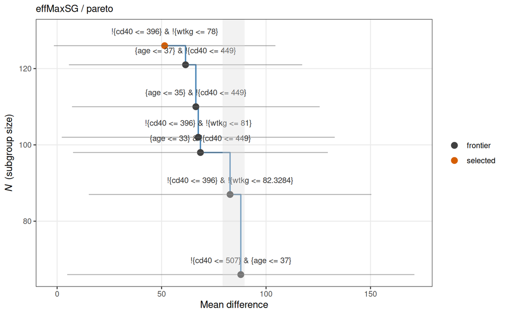

Pareto frontier — effMaxSG / pareto

```r
print(comparison$plots[[1]])
```

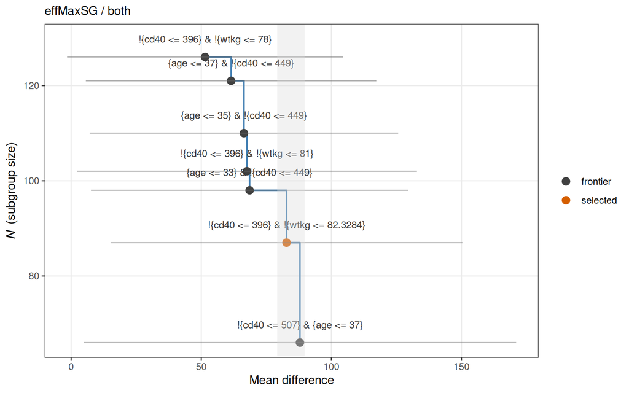

Pareto frontier — effMaxSG / both

```r
print(comparison$plots[[2]])
```

### 5.2.2 Side-by-Side Composition

```
`geom_path()`: Each group consists of only one observation.
ℹ Do you need to adjust the group aesthetic?
```

[figure not shown]

Pareto frontier across selection rules (side-by-side)

```r
print(comparison$plot_grid)
```

## 5.3 Combined Plot(s) by Matching Passing-Set Group

`compare_selection_rules()` groups configurations by their post-consistency passing set. When all configurations share one passing set, a single combined plot is built (`comparison$plot_combined`). When configurations fall into two or more matching groups – e.g. all `effMaxSG` runs agree, all `effMinSG` runs agree, but the two `sg_focus` values disagree on which candidates pass – a combined plot is built per group and stored in `comparison$plot_combined_subsets`. Each group’s plot labels its selected subgroups with `S<i>:` markers identifying the configuration(s) that picked them.

```
Passing sets fall into 1 matching group(s); one combined plot per group:

Group: effMaxSG / pareto + effMaxSG / both + effMinSG / pareto + effMinSG / both + eff / neighborhood + maxSG / neighborhood + minSG / neighborhood
```

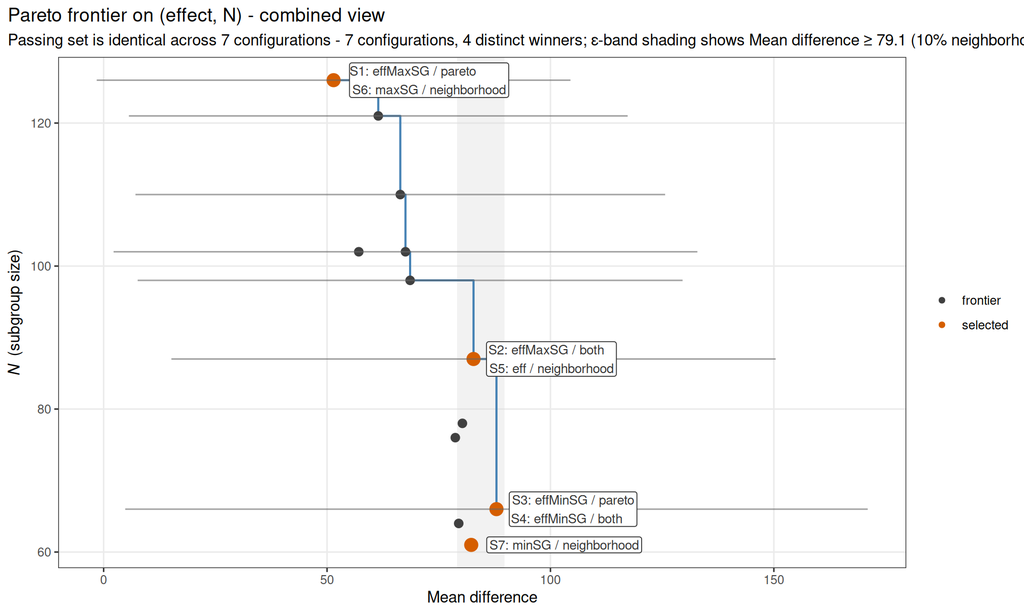

```
Note: Passing sets fall into 1 matching group(s) of sizes 7; no single combined plot covers all 8 configurations.  See $plot_combined_subsets for per-group plots.
```

```r
if (!is.null(comparison$plot_combined)) {
  cat("All configurations share one passing set; single combined plot:\n\n")
  print(comparison$plot_combined)
} else if (length(comparison$plot_combined_subsets) > 0L) {
  cat(sprintf("Passing sets fall into %d matching group(s); one combined plot per group:\n\n",
              length(comparison$plot_combined_subsets)))
  for (nm in names(comparison$plot_combined_subsets)) {
    cat(sprintf("Group: %s\n", nm))
    print(comparison$plot_combined_subsets[[nm]])
  }
  if (!is.null(comparison$combined_skip_reason)) {
    cat("\nNote: ", comparison$combined_skip_reason, "\n", sep = "")
  }
} else {
  cat("**No combined plot.**\n\n")
  if (!is.null(comparison$combined_skip_reason)) {
    cat("Reason:  ", comparison$combined_skip_reason, "\n\n", sep = "")
  }
  cat("See the side-by-side composition above as the alternative view.\n")
}
```

## 5.4 Frontier Tables

Per-combination Pareto-frontier table with split-derived and FSBC CIs. Selected subgroup is highlighted with ★.

```r
for (i in seq_len(n_combos)) {
  cat(sprintf("\n### `%s`\n\n", combo_labels[i]))
  tbl <- pareto_frontier_table(
    comparison$fs[[i]],
    ci_table = comparison$ci_tab[[i]],
    digits   = frontier_params$digits
  )
  print(tbl)
  cat("\n\n")
}
```

### 5.4.1 `effMaxSG / pareto`

Pareto frontier on (MD, N)

7 non-dominated candidate(s) | sg_focus = ‘hrMaxSG’ | MD shown on natural scale | diagnostic only

| S<sup>1,2</sup> | M.1 | M.2 | N | E | MD | P<sup>3</sup> | K | 95% CIs Naive | 95% CIs Split ~ | 95% CIs FSBC ~ |
| --- | --- | --- | --- | --- | --- | --- | --- | --- | --- | --- |
|  | !{cd40 <= 507} | {age <= 37} | 66 | 66 | 87.92 | 0.95 | 2 | (3.82, 172.02) | (4.83, 171.01) | 87.34 (4.25, 170.43) |
|  | !{cd40 <= 396} | !{wtkg <= 82.3284} | 87 | 87 | 82.78 | 0.97 | 2 | (14.81, 150.76) | (15.16, 150.40) | 82.94 (15.32, 150.56) |
|  | {age <= 33} | !{cd40 <= 449} | 98 | 98 | 68.59 | 0.95 | 2 | (5.81, 131.38) | (7.61, 129.57) | 68.41 (7.43, 129.39) |
|  | !{cd40 <= 396} | !{wtkg <= 81} | 102 | 102 | 67.55 | 0.94 | 2 | (4.02, 131.09) | (2.23, 132.88) | 67.66 (2.33, 132.99) |
|  | {age <= 35} | !{cd40 <= 449} | 110 | 110 | 66.40 | 0.96 | 2 | (8.65, 124.14) | (7.12, 125.67) | 66.41 (7.13, 125.68) |
|  | {age <= 37} | !{cd40 <= 449} | 121 | 121 | 61.47 | 0.96 | 2 | (7.27, 115.66) | (5.65, 117.28) | 61.36 (5.55, 117.17) |
| ★ | !{cd40 <= 396} | !{wtkg <= 78} | 126 | 126 | 51.47 | 0.91 | 2 | (-2.63, 105.56) | (-1.55, 104.48) | 51.40 (-1.61, 104.42) |

<sup>1</sup> S: selected subgroup (winner of the configured selection rule).  
<sup>2</sup> ★ marks the subgroup chosen by sg_focus = ‘hrMaxSG’.  
<sup>3</sup> P: Pcons (consistency probability).

### 5.4.2 `effMaxSG / both`

Pareto frontier on (MD, N)

7 non-dominated candidate(s) | sg_focus = ‘hrMaxSG’ | MD shown on natural scale | diagnostic only

| S<sup>1,2</sup> | M.1 | M.2 | N | E | MD | P<sup>3</sup> | K | 95% CIs Naive | 95% CIs Split ~ | 95% CIs FSBC ~ |
| --- | --- | --- | --- | --- | --- | --- | --- | --- | --- | --- |
|  | !{cd40 <= 507} | {age <= 37} | 66 | 66 | 87.92 | 0.95 | 2 | (3.82, 172.02) | (4.83, 171.01) | 87.34 (4.25, 170.43) |
| ★ | !{cd40 <= 396} | !{wtkg <= 82.3284} | 87 | 87 | 82.78 | 0.97 | 2 | (14.81, 150.76) | (15.16, 150.40) | 82.94 (15.32, 150.56) |
|  | {age <= 33} | !{cd40 <= 449} | 98 | 98 | 68.59 | 0.95 | 2 | (5.81, 131.38) | (7.61, 129.57) | 68.41 (7.43, 129.39) |
|  | !{cd40 <= 396} | !{wtkg <= 81} | 102 | 102 | 67.55 | 0.94 | 2 | (4.02, 131.09) | (2.23, 132.88) | 67.66 (2.33, 132.99) |
|  | {age <= 35} | !{cd40 <= 449} | 110 | 110 | 66.40 | 0.96 | 2 | (8.65, 124.14) | (7.12, 125.67) | 66.41 (7.13, 125.68) |
|  | {age <= 37} | !{cd40 <= 449} | 121 | 121 | 61.47 | 0.96 | 2 | (7.27, 115.66) | (5.65, 117.28) | 61.36 (5.55, 117.17) |
|  | !{cd40 <= 396} | !{wtkg <= 78} | 126 | 126 | 51.47 | 0.91 | 2 | (-2.63, 105.56) | (-1.55, 104.48) | 51.40 (-1.61, 104.42) |

<sup>1</sup> S: selected subgroup (winner of the configured selection rule).  
<sup>2</sup> ★ marks the subgroup chosen by sg_focus = ‘hrMaxSG’.  
<sup>3</sup> P: Pcons (consistency probability).

### 5.4.3 `effMinSG / pareto`

Pareto frontier on (MD, N)

7 non-dominated candidate(s) | sg_focus = ‘hrMinSG’ | MD shown on natural scale | diagnostic only

| S<sup>1,2</sup> | M.1 | M.2 | N | E | MD | P<sup>3</sup> | K | 95% CIs Naive | 95% CIs Split ~ | 95% CIs FSBC ~ |
| --- | --- | --- | --- | --- | --- | --- | --- | --- | --- | --- |
| ★ | !{cd40 <= 507} | {age <= 37} | 66 | 66 | 87.92 | 0.95 | 2 | (3.82, 172.02) | (4.83, 171.01) | 87.34 (4.25, 170.43) |
|  | !{cd40 <= 396} | !{wtkg <= 82.3284} | 87 | 87 | 82.78 | 0.97 | 2 | (14.81, 150.76) | (15.16, 150.40) | 82.94 (15.32, 150.56) |
|  | {age <= 33} | !{cd40 <= 449} | 98 | 98 | 68.59 | 0.95 | 2 | (5.81, 131.38) | (7.61, 129.57) | 68.41 (7.43, 129.39) |
|  | !{cd40 <= 396} | !{wtkg <= 81} | 102 | 102 | 67.55 | 0.94 | 2 | (4.02, 131.09) | (2.23, 132.88) | 67.66 (2.33, 132.99) |
|  | {age <= 35} | !{cd40 <= 449} | 110 | 110 | 66.40 | 0.96 | 2 | (8.65, 124.14) | (7.12, 125.67) | 66.41 (7.13, 125.68) |
|  | {age <= 37} | !{cd40 <= 449} | 121 | 121 | 61.47 | 0.96 | 2 | (7.27, 115.66) | (5.65, 117.28) | 61.36 (5.55, 117.17) |
|  | !{cd40 <= 396} | !{wtkg <= 78} | 126 | 126 | 51.47 | 0.91 | 2 | (-2.63, 105.56) | (-1.55, 104.48) | 51.40 (-1.61, 104.42) |

<sup>1</sup> S: selected subgroup (winner of the configured selection rule).  
<sup>2</sup> ★ marks the subgroup chosen by sg_focus = ‘hrMinSG’.  
<sup>3</sup> P: Pcons (consistency probability).

### 5.4.4 `effMinSG / both`

Pareto frontier on (MD, N)

7 non-dominated candidate(s) | sg_focus = ‘hrMinSG’ | MD shown on natural scale | diagnostic only

| S<sup>1,2</sup> | M.1 | M.2 | N | E | MD | P<sup>3</sup> | K | 95% CIs Naive | 95% CIs Split ~ | 95% CIs FSBC ~ |
| --- | --- | --- | --- | --- | --- | --- | --- | --- | --- | --- |
| ★ | !{cd40 <= 507} | {age <= 37} | 66 | 66 | 87.92 | 0.95 | 2 | (3.82, 172.02) | (4.83, 171.01) | 87.34 (4.25, 170.43) |
|  | !{cd40 <= 396} | !{wtkg <= 82.3284} | 87 | 87 | 82.78 | 0.97 | 2 | (14.81, 150.76) | (15.16, 150.40) | 82.94 (15.32, 150.56) |
|  | {age <= 33} | !{cd40 <= 449} | 98 | 98 | 68.59 | 0.95 | 2 | (5.81, 131.38) | (7.61, 129.57) | 68.41 (7.43, 129.39) |
|  | !{cd40 <= 396} | !{wtkg <= 81} | 102 | 102 | 67.55 | 0.94 | 2 | (4.02, 131.09) | (2.23, 132.88) | 67.66 (2.33, 132.99) |
|  | {age <= 35} | !{cd40 <= 449} | 110 | 110 | 66.40 | 0.96 | 2 | (8.65, 124.14) | (7.12, 125.67) | 66.41 (7.13, 125.68) |
|  | {age <= 37} | !{cd40 <= 449} | 121 | 121 | 61.47 | 0.96 | 2 | (7.27, 115.66) | (5.65, 117.28) | 61.36 (5.55, 117.17) |
|  | !{cd40 <= 396} | !{wtkg <= 78} | 126 | 126 | 51.47 | 0.91 | 2 | (-2.63, 105.56) | (-1.55, 104.48) | 51.40 (-1.61, 104.42) |

<sup>1</sup> S: selected subgroup (winner of the configured selection rule).  
<sup>2</sup> ★ marks the subgroup chosen by sg_focus = ‘hrMinSG’.  
<sup>3</sup> P: Pcons (consistency probability).

### 5.4.5 `eff / neighborhood`

Pareto frontier on (MD, N)

7 non-dominated candidate(s) | sg_focus = ‘hr’ | MD shown on natural scale | diagnostic only

| S<sup>1,2</sup> | M.1 | M.2 | N | E | MD | P<sup>3</sup> | K | 95% CIs Naive | 95% CIs Split ~ | 95% CIs FSBC ~ |
| --- | --- | --- | --- | --- | --- | --- | --- | --- | --- | --- |
|  | !{cd40 <= 507} | {age <= 37} | 66 | 66 | 87.92 | 0.95 | 2 | (3.82, 172.02) | (4.83, 171.01) | 87.34 (4.25, 170.43) |
| ★ | !{cd40 <= 396} | !{wtkg <= 82.3284} | 87 | 87 | 82.78 | 0.97 | 2 | (14.81, 150.76) | (15.16, 150.40) | 82.94 (15.32, 150.56) |
|  | {age <= 33} | !{cd40 <= 449} | 98 | 98 | 68.59 | 0.95 | 2 | (5.81, 131.38) | (7.61, 129.57) | 68.41 (7.43, 129.39) |
|  | !{cd40 <= 396} | !{wtkg <= 81} | 102 | 102 | 67.55 | 0.94 | 2 | (4.02, 131.09) | (2.23, 132.88) | 67.66 (2.33, 132.99) |
|  | {age <= 35} | !{cd40 <= 449} | 110 | 110 | 66.40 | 0.96 | 2 | (8.65, 124.14) | (7.12, 125.67) | 66.41 (7.13, 125.68) |
|  | {age <= 37} | !{cd40 <= 449} | 121 | 121 | 61.47 | 0.96 | 2 | (7.27, 115.66) | (5.65, 117.28) | 61.36 (5.55, 117.17) |
|  | !{cd40 <= 396} | !{wtkg <= 78} | 126 | 126 | 51.47 | 0.91 | 2 | (-2.63, 105.56) | (-1.55, 104.48) | 51.40 (-1.61, 104.42) |

<sup>1</sup> S: selected subgroup (winner of the configured selection rule).  
<sup>2</sup> ★ marks the subgroup chosen by sg_focus = ‘hr’.  
<sup>3</sup> P: Pcons (consistency probability).

### 5.4.6 `maxSG / neighborhood`

Pareto frontier on (MD, N)

7 non-dominated candidate(s) | sg_focus = ‘maxSG’ | MD shown on natural scale | diagnostic only

| S<sup>1,2</sup> | M.1 | M.2 | N | E | MD | P<sup>3</sup> | K | 95% CIs Naive | 95% CIs Split ~ | 95% CIs FSBC ~ |
| --- | --- | --- | --- | --- | --- | --- | --- | --- | --- | --- |
|  | !{cd40 <= 507} | {age <= 37} | 66 | 66 | 87.92 | 0.95 | 2 | (3.82, 172.02) | (4.83, 171.01) | 87.34 (4.25, 170.43) |
|  | !{cd40 <= 396} | !{wtkg <= 82.3284} | 87 | 87 | 82.78 | 0.97 | 2 | (14.81, 150.76) | (15.16, 150.40) | 82.94 (15.32, 150.56) |
|  | {age <= 33} | !{cd40 <= 449} | 98 | 98 | 68.59 | 0.95 | 2 | (5.81, 131.38) | (7.61, 129.57) | 68.41 (7.43, 129.39) |
|  | !{cd40 <= 396} | !{wtkg <= 81} | 102 | 102 | 67.55 | 0.94 | 2 | (4.02, 131.09) | (2.23, 132.88) | 67.66 (2.33, 132.99) |
|  | {age <= 35} | !{cd40 <= 449} | 110 | 110 | 66.40 | 0.96 | 2 | (8.65, 124.14) | (7.12, 125.67) | 66.41 (7.13, 125.68) |
|  | {age <= 37} | !{cd40 <= 449} | 121 | 121 | 61.47 | 0.96 | 2 | (7.27, 115.66) | (5.65, 117.28) | 61.36 (5.55, 117.17) |
| ★ | !{cd40 <= 396} | !{wtkg <= 78} | 126 | 126 | 51.47 | 0.91 | 2 | (-2.63, 105.56) | (-1.55, 104.48) | 51.40 (-1.61, 104.42) |

<sup>1</sup> S: selected subgroup (winner of the configured selection rule).  
<sup>2</sup> ★ marks the subgroup chosen by sg_focus = ‘maxSG’.  
<sup>3</sup> P: Pcons (consistency probability).

### 5.4.7 `minSG / neighborhood`

Pareto frontier on (MD, N)

7 non-dominated candidate(s) | sg_focus = ‘minSG’ | MD shown on natural scale | diagnostic only

| S<sup>1,2</sup> | M.1 | M.2 | N | E | MD | P<sup>3</sup> | K | 95% CIs Naive | 95% CIs Split ~ | 95% CIs FSBC ~ |
| --- | --- | --- | --- | --- | --- | --- | --- | --- | --- | --- |
|  | !{cd40 <= 507} | {age <= 37} | 66 | 66 | 87.92 | 0.95 | 2 | (3.82, 172.02) | (4.83, 171.01) | 87.34 (4.25, 170.43) |
|  | !{cd40 <= 396} | !{wtkg <= 82.3284} | 87 | 87 | 82.78 | 0.97 | 2 | (14.81, 150.76) | (15.16, 150.40) | 82.94 (15.32, 150.56) |
|  | {age <= 33} | !{cd40 <= 449} | 98 | 98 | 68.59 | 0.95 | 2 | (5.81, 131.38) | (7.61, 129.57) | 68.41 (7.43, 129.39) |
|  | !{cd40 <= 396} | !{wtkg <= 81} | 102 | 102 | 67.55 | 0.94 | 2 | (4.02, 131.09) | (2.23, 132.88) | 67.66 (2.33, 132.99) |
|  | {age <= 35} | !{cd40 <= 449} | 110 | 110 | 66.40 | 0.96 | 2 | (8.65, 124.14) | (7.12, 125.67) | 66.41 (7.13, 125.68) |
|  | {age <= 37} | !{cd40 <= 449} | 121 | 121 | 61.47 | 0.96 | 2 | (7.27, 115.66) | (5.65, 117.28) | 61.36 (5.55, 117.17) |
|  | !{cd40 <= 396} | !{wtkg <= 78} | 126 | 126 | 51.47 | 0.91 | 2 | (-2.63, 105.56) | (-1.55, 104.48) | 51.40 (-1.61, 104.42) |

<sup>1</sup> S: selected subgroup (winner of the configured selection rule).  
<sup>2</sup> ★ marks the subgroup chosen by sg_focus = ‘minSG’.  
<sup>3</sup> P: Pcons (consistency probability).

### 5.4.8 `maxeffCons / neighborhood`

Pareto frontier on (MD, N)

1 non-dominated candidate(s) | sg_focus = ‘maxeffCons’ | MD shown on natural scale | diagnostic only

| S<sup>1,2</sup> | M.1 | M.2 | N | E | MD | P<sup>3</sup> | K | 95% CIs Naive | 95% CIs Split ~ | 95% CIs FSBC ~ |
| --- | --- | --- | --- | --- | --- | --- | --- | --- | --- | --- |
| ★ | !{cd40 <= 507} | {age <= 37} | 66 | 66 | 87.92 | 0.95 | 2 | (3.82, 172.02) | (4.83, 171.01) | 87.34 (4.25, 170.43) |

<sup>1</sup> S: selected subgroup (winner of the configured selection rule).  
<sup>2</sup> ★ marks the subgroup chosen by sg_focus = ‘maxeffCons’.  
<sup>3</sup> P: Pcons (consistency probability).

## 5.5 Selection Narratives

`explain_pareto_selection()` produces a verbal account of why the selected subgroup wins on the configured lexicographic criterion relative to the other non-dominated candidates. Reading the two narratives together highlights which axis of the lex key the two rules tie-broke on differently.

```r
for (i in seq_len(n_combos)) {
  cat(sprintf("\n### `%s`\n\n", combo_labels[i]))
  cat(explain_pareto_selection(
    comparison$fs[[i]],
    ci_table = comparison$ci_tab[[i]],
    digits   = frontier_params$digits
  ))
  cat("\n\n")
}
```

### 5.5.1 `effMaxSG / pareto`

**Selection criterion.** The configured criterion is largest-N among non-dominated candidates (sg_focus = “hrMaxSG”) under the Pareto-non-dominance rule. Within the eligible set, ties on N are broken by Pcons, then by effect strength, then by parsimony (smaller K).

**Selected subgroup.** !{cd40 <= 396} AND !{wtkg <= 78} (mean difference = 51.47, N = 126, Pcons = 0.91, K = 2). This is the largest-N candidate in the eligible set among non-dominated frontier candidates. The Naive 95% CI for the mean difference on this subgroup is (-2.63, 105.56).

**Non-selected frontier candidates** (ordered by closeness to winning):

- **{age <= 37} AND !{cd40 <= 449}** (mean difference = 61.47, N = 121, Pcons = 0.96, K = 2). Smaller subgroup (N=121 vs N=126, 5 fewer subjects). N is the primary tiebreaker among non-dominated candidates, so this candidate’s stronger effect could not overcome the size loss.
- **{age <= 35} AND !{cd40 <= 449}** (mean difference = 66.40, N = 110, Pcons = 0.96, K = 2). Smaller subgroup (N=110 vs N=126, 16 fewer subjects). N is the primary tiebreaker among non-dominated candidates, so this candidate’s stronger effect could not overcome the size loss.
- **!{cd40 <= 396} AND !{wtkg <= 81}** (mean difference = 67.55, N = 102, Pcons = 0.94, K = 2). Smaller subgroup (N=102 vs N=126, 24 fewer subjects). N is the primary tiebreaker among non-dominated candidates, so this candidate’s stronger effect could not overcome the size loss.
- **{age <= 33} AND !{cd40 <= 449}** (mean difference = 68.59, N = 98, Pcons = 0.95, K = 2). Smaller subgroup (N=98 vs N=126, 28 fewer subjects). N is the primary tiebreaker among non-dominated candidates, so this candidate’s stronger effect could not overcome the size loss.
- **!{cd40 <= 396} AND !{wtkg <= 82.3284}** (mean difference = 82.78, N = 87, Pcons = 0.97, K = 2). Smaller subgroup (N=87 vs N=126, 39 fewer subjects). N is the primary tiebreaker among non-dominated candidates, so this candidate’s stronger effect could not overcome the size loss.
- **!{cd40 <= 507} AND {age <= 37}** (mean difference = 87.92, N = 66, Pcons = 0.95, K = 2). Smaller subgroup (N=66 vs N=126, 60 fewer subjects). N is the primary tiebreaker among non-dominated candidates, so this candidate’s stronger effect could not overcome the size loss.

### 5.5.2 `effMaxSG / both`

**Selection criterion.** The configured criterion is largest-N within the effect-size band (sg_focus = “hrMaxSG”) under the intersection of effect-band and Pareto-non-dominance rules. The effect-size band requires mean difference within 10% of the maximum on the frontier (i.e., mean difference >= 79.13). Within the eligible set, ties on N are broken by Pcons, then by effect strength, then by parsimony (smaller K).

**Selected subgroup.** !{cd40 <= 396} AND !{wtkg <= 82.3284} (mean difference = 82.78, N = 87, Pcons = 0.97, K = 2). This is the largest-N candidate in the eligible set among non-dominated frontier candidates. The Naive 95% CI for the mean difference on this subgroup is (14.81, 150.76).

**Non-selected frontier candidates** (ordered by closeness to winning):

- **!{cd40 <= 507} AND {age <= 37}** (mean difference = 87.92, N = 66, Pcons = 0.95, K = 2). Smaller subgroup (N=66 vs N=87, 21 fewer subjects). N is the primary tiebreaker once the band is satisfied, so this candidate’s stronger effect could not overcome the size loss.
- **{age <= 33} AND !{cd40 <= 449}** (mean difference = 68.59, N = 98, Pcons = 0.95, K = 2). fell outside the effect-size band (mean difference = 68.59 below the floor); excluded before the N tiebreaker even applies.
- **!{cd40 <= 396} AND !{wtkg <= 81}** (mean difference = 67.55, N = 102, Pcons = 0.94, K = 2). fell outside the effect-size band (mean difference = 67.55 below the floor); excluded before the N tiebreaker even applies.
- **{age <= 35} AND !{cd40 <= 449}** (mean difference = 66.40, N = 110, Pcons = 0.96, K = 2). fell outside the effect-size band (mean difference = 66.40 below the floor); excluded before the N tiebreaker even applies.
- **{age <= 37} AND !{cd40 <= 449}** (mean difference = 61.47, N = 121, Pcons = 0.96, K = 2). fell outside the effect-size band (mean difference = 61.47 below the floor); excluded before the N tiebreaker even applies.
- **!{cd40 <= 396} AND !{wtkg <= 78}** (mean difference = 51.47, N = 126, Pcons = 0.91, K = 2). fell outside the effect-size band (mean difference = 51.47 below the floor); excluded before the N tiebreaker even applies.

### 5.5.3 `effMinSG / pareto`

**Selection criterion.** The configured criterion is smallest-N among non-dominated candidates (sg_focus = “hrMinSG”) under the Pareto-non-dominance rule. Within the eligible set, ties on N are broken by Pcons, then by effect strength, then by parsimony (smaller K).

**Selected subgroup.** !{cd40 <= 507} AND {age <= 37} (mean difference = 87.92, N = 66, Pcons = 0.95, K = 2). This is the smallest-N candidate in the eligible set among non-dominated frontier candidates. The Naive 95% CI for the mean difference on this subgroup is (3.82, 172.02).

**Non-selected frontier candidates** (ordered by closeness to winning):

- **!{cd40 <= 396} AND !{wtkg <= 82.3284}** (mean difference = 82.78, N = 87, Pcons = 0.97, K = 2). Larger subgroup (N=87 vs N=66, 21 more subjects). N is the primary tiebreaker among non-dominated candidates, so this candidate’s comparable effect could not overcome the size loss.
- **{age <= 33} AND !{cd40 <= 449}** (mean difference = 68.59, N = 98, Pcons = 0.95, K = 2). Larger subgroup (N=98 vs N=66, 32 more subjects). N is the primary tiebreaker among non-dominated candidates, so this candidate’s comparable effect could not overcome the size loss.
- **!{cd40 <= 396} AND !{wtkg <= 81}** (mean difference = 67.55, N = 102, Pcons = 0.94, K = 2). Larger subgroup (N=102 vs N=66, 36 more subjects). N is the primary tiebreaker among non-dominated candidates, so this candidate’s comparable effect could not overcome the size loss.
- **{age <= 35} AND !{cd40 <= 449}** (mean difference = 66.40, N = 110, Pcons = 0.96, K = 2). Larger subgroup (N=110 vs N=66, 44 more subjects). N is the primary tiebreaker among non-dominated candidates, so this candidate’s comparable effect could not overcome the size loss.
- **{age <= 37} AND !{cd40 <= 449}** (mean difference = 61.47, N = 121, Pcons = 0.96, K = 2). Larger subgroup (N=121 vs N=66, 55 more subjects). N is the primary tiebreaker among non-dominated candidates, so this candidate’s comparable effect could not overcome the size loss.
- **!{cd40 <= 396} AND !{wtkg <= 78}** (mean difference = 51.47, N = 126, Pcons = 0.91, K = 2). Larger subgroup (N=126 vs N=66, 60 more subjects). N is the primary tiebreaker among non-dominated candidates, so this candidate’s comparable effect could not overcome the size loss.

### 5.5.4 `effMinSG / both`

**Selection criterion.** The configured criterion is smallest-N within the effect-size band (sg_focus = “hrMinSG”) under the intersection of effect-band and Pareto-non-dominance rules. The effect-size band requires mean difference within 10% of the maximum on the frontier (i.e., mean difference >= 79.13). Within the eligible set, ties on N are broken by Pcons, then by effect strength, then by parsimony (smaller K).

**Selected subgroup.** !{cd40 <= 507} AND {age <= 37} (mean difference = 87.92, N = 66, Pcons = 0.95, K = 2). This is the smallest-N candidate in the eligible set among non-dominated frontier candidates. The Naive 95% CI for the mean difference on this subgroup is (3.82, 172.02).

**Non-selected frontier candidates** (ordered by closeness to winning):

- **!{cd40 <= 396} AND !{wtkg <= 82.3284}** (mean difference = 82.78, N = 87, Pcons = 0.97, K = 2). Larger subgroup (N=87 vs N=66, 21 more subjects). N is the primary tiebreaker once the band is satisfied, so this candidate’s comparable effect could not overcome the size loss.
- **{age <= 33} AND !{cd40 <= 449}** (mean difference = 68.59, N = 98, Pcons = 0.95, K = 2). fell outside the effect-size band (mean difference = 68.59 below the floor); excluded before the N tiebreaker even applies.
- **!{cd40 <= 396} AND !{wtkg <= 81}** (mean difference = 67.55, N = 102, Pcons = 0.94, K = 2). fell outside the effect-size band (mean difference = 67.55 below the floor); excluded before the N tiebreaker even applies.
- **{age <= 35} AND !{cd40 <= 449}** (mean difference = 66.40, N = 110, Pcons = 0.96, K = 2). fell outside the effect-size band (mean difference = 66.40 below the floor); excluded before the N tiebreaker even applies.
- **{age <= 37} AND !{cd40 <= 449}** (mean difference = 61.47, N = 121, Pcons = 0.96, K = 2). fell outside the effect-size band (mean difference = 61.47 below the floor); excluded before the N tiebreaker even applies.
- **!{cd40 <= 396} AND !{wtkg <= 78}** (mean difference = 51.47, N = 126, Pcons = 0.91, K = 2). fell outside the effect-size band (mean difference = 51.47 below the floor); excluded before the N tiebreaker even applies.

### 5.5.5 `eff / neighborhood`

**Selection criterion.** The configured criterion is highest-consistency (sg_focus = “hr”) under the effect-size neighborhood rule.

**Selected subgroup.** !{cd40 <= 396} AND !{wtkg <= 82.3284} (mean difference = 82.78, N = 87, Pcons = 0.97, K = 2). This is the candidate with the highest Pcons among non-dominated frontier candidates. The Naive 95% CI for the mean difference on this subgroup is (14.81, 150.76).

**Non-selected frontier candidates** (ordered by closeness to winning):

- **{age <= 35} AND !{cd40 <= 449}** (mean difference = 66.40, N = 110, Pcons = 0.96, K = 2). Lower consistency (Pcons=0.960 vs 0.970); Pcons is the secondary tiebreaker after N.
- **{age <= 37} AND !{cd40 <= 449}** (mean difference = 61.47, N = 121, Pcons = 0.96, K = 2). Lower consistency (Pcons=0.960 vs 0.970); Pcons is the secondary tiebreaker after N.
- **!{cd40 <= 507} AND {age <= 37}** (mean difference = 87.92, N = 66, Pcons = 0.95, K = 2). Lower consistency (Pcons=0.950 vs 0.970); Pcons is the secondary tiebreaker after N.
- **{age <= 33} AND !{cd40 <= 449}** (mean difference = 68.59, N = 98, Pcons = 0.95, K = 2). Lower consistency (Pcons=0.950 vs 0.970); Pcons is the secondary tiebreaker after N.
- **!{cd40 <= 396} AND !{wtkg <= 81}** (mean difference = 67.55, N = 102, Pcons = 0.94, K = 2). Lower consistency (Pcons=0.940 vs 0.970); Pcons is the secondary tiebreaker after N.
- **!{cd40 <= 396} AND !{wtkg <= 78}** (mean difference = 51.47, N = 126, Pcons = 0.91, K = 2). Lower consistency (Pcons=0.910 vs 0.970); Pcons is the secondary tiebreaker after N.

### 5.5.6 `maxSG / neighborhood`

**Selection criterion.** The configured criterion is largest-N (sg_focus = “maxSG”) under the effect-size neighborhood rule. Ties on N are broken by Pcons, then by parsimony (smaller K).

**Selected subgroup.** !{cd40 <= 396} AND !{wtkg <= 78} (mean difference = 51.47, N = 126, Pcons = 0.91, K = 2). This is the largest-N candidate among non-dominated frontier candidates. The Naive 95% CI for the mean difference on this subgroup is (-2.63, 105.56).

**Non-selected frontier candidates** (ordered by closeness to winning):

- **{age <= 37} AND !{cd40 <= 449}** (mean difference = 61.47, N = 121, Pcons = 0.96, K = 2). Smaller subgroup (N=121 vs N=126, 5 fewer subjects). N is the primary tiebreaker among non-dominated candidates, so this candidate’s stronger effect could not overcome the size loss.
- **{age <= 35} AND !{cd40 <= 449}** (mean difference = 66.40, N = 110, Pcons = 0.96, K = 2). Smaller subgroup (N=110 vs N=126, 16 fewer subjects). N is the primary tiebreaker among non-dominated candidates, so this candidate’s stronger effect could not overcome the size loss.
- **!{cd40 <= 396} AND !{wtkg <= 81}** (mean difference = 67.55, N = 102, Pcons = 0.94, K = 2). Smaller subgroup (N=102 vs N=126, 24 fewer subjects). N is the primary tiebreaker among non-dominated candidates, so this candidate’s stronger effect could not overcome the size loss.
- **{age <= 33} AND !{cd40 <= 449}** (mean difference = 68.59, N = 98, Pcons = 0.95, K = 2). Smaller subgroup (N=98 vs N=126, 28 fewer subjects). N is the primary tiebreaker among non-dominated candidates, so this candidate’s stronger effect could not overcome the size loss.
- **!{cd40 <= 396} AND !{wtkg <= 82.3284}** (mean difference = 82.78, N = 87, Pcons = 0.97, K = 2). Smaller subgroup (N=87 vs N=126, 39 fewer subjects). N is the primary tiebreaker among non-dominated candidates, so this candidate’s stronger effect could not overcome the size loss.
- **!{cd40 <= 507} AND {age <= 37}** (mean difference = 87.92, N = 66, Pcons = 0.95, K = 2). Smaller subgroup (N=66 vs N=126, 60 fewer subjects). N is the primary tiebreaker among non-dominated candidates, so this candidate’s stronger effect could not overcome the size loss.

### 5.5.7 `minSG / neighborhood`

**Selection criterion.** The configured criterion is smallest-N (sg_focus = “minSG”) under the effect-size neighborhood rule. Ties on N are broken by Pcons, then by parsimony (smaller K).

**Selected subgroup.** The selected subgroup does not appear on the Pareto frontier shown above. This is allowed under `hrMinSG`, which may pick a small-N candidate that is itself dominated by a larger-N candidate with similar effect. The frontier rows below describe the non-dominated alternatives that were evaluated but not chosen.

### 5.5.8 `maxeffCons / neighborhood`

**Selection criterion.** The configured criterion is maxeffCons under the effect-size neighborhood rule.

**Selected subgroup.** !{cd40 <= 507} AND {age <= 37} (mean difference = 87.92, N = 66, Pcons = 0.95, K = 2). This is the candidate satisfying the selection rule among non-dominated frontier candidates. The Naive 95% CI for the mean difference on this subgroup is (3.82, 172.02).

**Non-selected candidates.** The frontier has a single candidate, so no comparison applies.

# 6 Rich Post-Consistency View

The `include_dominated = TRUE` argument to `pareto_frontier_table()` shows **all** passing candidates (not just the frontier), with `on_frontier` and `in_band` flag columns added. This is the post-hoc analog of the `CANDIDATE EVALUATION SUMMARY` banner printed during the run.

```r
for (i in seq_len(n_combos)) {
  cat(sprintf("\n### `%s`\n\n", combo_labels[i]))
  tbl <- pareto_frontier_table(
    comparison$fs[[i]],
    ci_table          = comparison$ci_tab[[i]],
    include_dominated = TRUE,
    digits            = frontier_params$digits
  )
  print(tbl)
  cat("\n\n")
}
```

### 6.0.1 `effMaxSG / pareto`

Pareto frontier on (MD, N)

12 non-dominated candidate(s) | sg_focus = ‘hrMaxSG’ | MD shown on natural scale | diagnostic only

| S<sup>1,2</sup> | M.1 | M.2 | N | E | MD | P<sup>3</sup> | K | OF<sup>4</sup> | 95% CIs Naive | 95% CIs Split ~ | 95% CIs FSBC ~ |
| --- | --- | --- | --- | --- | --- | --- | --- | --- | --- | --- | --- |
| ★ | !{cd40 <= 396} | !{wtkg <= 78} | 126 | 126 | 51.47 | 0.91 | 2 | ★ | (-2.63, 105.56) | (-1.55, 104.48) | 51.40 (-1.61, 104.42) |
|  | {age <= 37} | !{cd40 <= 449} | 121 | 121 | 61.47 | 0.96 | 2 | ★ | (7.27, 115.66) | (5.65, 117.28) | 61.36 (5.55, 117.17) |
|  | {age <= 35} | !{cd40 <= 449} | 110 | 110 | 66.40 | 0.96 | 2 | ★ | (8.65, 124.14) | (7.12, 125.67) | 66.41 (7.13, 125.68) |
|  | !{cd40 <= 396} | !{wtkg <= 81} | 102 | 102 | 67.55 | 0.94 | 2 | ★ | (4.02, 131.09) | (2.23, 132.88) | 67.66 (2.33, 132.99) |
|  | {age <= 33} | !{cd40 <= 449} | 98 | 98 | 68.59 | 0.95 | 2 | ★ | (5.81, 131.38) | (7.61, 129.57) | 68.41 (7.43, 129.39) |
|  | !{cd40 <= 396} | !{wtkg <= 82.3284} | 87 | 87 | 82.78 | 0.97 | 2 | ★ | (14.81, 150.76) | (15.16, 150.40) | 82.94 (15.32, 150.56) |
|  | !{cd40 <= 507} | {age <= 37} | 66 | 66 | 87.92 | 0.95 | 2 | ★ | (3.82, 172.02) | (4.83, 171.01) | 87.34 (4.25, 170.43) |
|  | !{wtkg <= 82.3284} | !{cd40 <= 380} | 102 | 102 | 57.10 | 0.90 | 2 |  | NA | NA | NA |
|  | !{cd40 <= 413} | !{wtkg <= 82.3284} | 78 | 78 | 80.29 | 0.95 | 2 |  | NA | NA | NA |
|  | !{cd40 <= 507} | {age <= 40} | 76 | 76 | 78.71 | 0.93 | 2 |  | NA | NA | NA |
|  | !{cd40 <= 396} | !{wtkg <= 86} | 64 | 64 | 79.47 | 0.92 | 2 |  | NA | NA | NA |
|  | !{cd40 <= 507} | !{wtkg <= 73} | 61 | 61 | 82.27 | 0.93 | 2 |  | NA | NA | NA |

<sup>1</sup> S: selected subgroup (winner of the configured selection rule).  
<sup>2</sup> ★ marks the subgroup chosen by sg_focus = ‘hrMaxSG’.  
<sup>3</sup> P: Pcons (consistency probability).  
<sup>4</sup> OF: on Pareto frontier (non-dominated on (effect, N)).

### 6.0.2 `effMaxSG / both`

Pareto frontier on (MD, N)

12 non-dominated candidate(s) | sg_focus = ‘hrMaxSG’ | MD shown on natural scale | diagnostic only

| S<sup>1,2</sup> | M.1 | M.2 | N | E | MD | P<sup>3</sup> | K | OF<sup>4</sup> | IB<sup>5</sup> | 95% CIs Naive | 95% CIs Split ~ | 95% CIs FSBC ~ |
| --- | --- | --- | --- | --- | --- | --- | --- | --- | --- | --- | --- | --- |
| ★ | !{cd40 <= 396} | !{wtkg <= 82.3284} | 87 | 87 | 82.78 | 0.97 | 2 | ★ | ★ | (14.81, 150.76) | (15.16, 150.40) | 82.94 (15.32, 150.56) |
|  | !{cd40 <= 507} | {age <= 37} | 66 | 66 | 87.92 | 0.95 | 2 | ★ | ★ | (3.82, 172.02) | (4.83, 171.01) | 87.34 (4.25, 170.43) |
|  | !{cd40 <= 396} | !{wtkg <= 78} | 126 | 126 | 51.47 | 0.91 | 2 | ★ |  | (-2.63, 105.56) | (-1.55, 104.48) | 51.40 (-1.61, 104.42) |
|  | {age <= 37} | !{cd40 <= 449} | 121 | 121 | 61.47 | 0.96 | 2 | ★ |  | (7.27, 115.66) | (5.65, 117.28) | 61.36 (5.55, 117.17) |
|  | {age <= 35} | !{cd40 <= 449} | 110 | 110 | 66.40 | 0.96 | 2 | ★ |  | (8.65, 124.14) | (7.12, 125.67) | 66.41 (7.13, 125.68) |
|  | !{cd40 <= 396} | !{wtkg <= 81} | 102 | 102 | 67.55 | 0.94 | 2 | ★ |  | (4.02, 131.09) | (2.23, 132.88) | 67.66 (2.33, 132.99) |
|  | !{wtkg <= 82.3284} | !{cd40 <= 380} | 102 | 102 | 57.10 | 0.90 | 2 |  |  | NA | NA | NA |
|  | {age <= 33} | !{cd40 <= 449} | 98 | 98 | 68.59 | 0.95 | 2 | ★ |  | (5.81, 131.38) | (7.61, 129.57) | 68.41 (7.43, 129.39) |
|  | !{cd40 <= 413} | !{wtkg <= 82.3284} | 78 | 78 | 80.29 | 0.95 | 2 |  | ★ | NA | NA | NA |
|  | !{cd40 <= 507} | {age <= 40} | 76 | 76 | 78.71 | 0.93 | 2 |  |  | NA | NA | NA |
|  | !{cd40 <= 396} | !{wtkg <= 86} | 64 | 64 | 79.47 | 0.92 | 2 |  | ★ | NA | NA | NA |
|  | !{cd40 <= 507} | !{wtkg <= 73} | 61 | 61 | 82.27 | 0.93 | 2 |  | ★ | NA | NA | NA |

<sup>1</sup> S: selected subgroup (winner of the configured selection rule).  
<sup>2</sup> ★ marks the subgroup chosen by sg_focus = ‘hrMaxSG’.  
<sup>3</sup> P: Pcons (consistency probability).  
<sup>4</sup> OF: on Pareto frontier (non-dominated on (effect, N)).  
<sup>5</sup> IB: in effect-size neighborhood band.

### 6.0.3 `effMinSG / pareto`

Pareto frontier on (MD, N)

12 non-dominated candidate(s) | sg_focus = ‘hrMinSG’ | MD shown on natural scale | diagnostic only

| S<sup>1,2</sup> | M.1 | M.2 | N | E | MD | P<sup>3</sup> | K | OF<sup>4</sup> | 95% CIs Naive | 95% CIs Split ~ | 95% CIs FSBC ~ |
| --- | --- | --- | --- | --- | --- | --- | --- | --- | --- | --- | --- |
| ★ | !{cd40 <= 507} | {age <= 37} | 66 | 66 | 87.92 | 0.95 | 2 | ★ | (3.82, 172.02) | (4.83, 171.01) | 87.34 (4.25, 170.43) |
|  | !{cd40 <= 396} | !{wtkg <= 82.3284} | 87 | 87 | 82.78 | 0.97 | 2 | ★ | (14.81, 150.76) | (15.16, 150.40) | 82.94 (15.32, 150.56) |
|  | {age <= 33} | !{cd40 <= 449} | 98 | 98 | 68.59 | 0.95 | 2 | ★ | (5.81, 131.38) | (7.61, 129.57) | 68.41 (7.43, 129.39) |
|  | !{cd40 <= 396} | !{wtkg <= 81} | 102 | 102 | 67.55 | 0.94 | 2 | ★ | (4.02, 131.09) | (2.23, 132.88) | 67.66 (2.33, 132.99) |
|  | {age <= 35} | !{cd40 <= 449} | 110 | 110 | 66.40 | 0.96 | 2 | ★ | (8.65, 124.14) | (7.12, 125.67) | 66.41 (7.13, 125.68) |
|  | {age <= 37} | !{cd40 <= 449} | 121 | 121 | 61.47 | 0.96 | 2 | ★ | (7.27, 115.66) | (5.65, 117.28) | 61.36 (5.55, 117.17) |
|  | !{cd40 <= 396} | !{wtkg <= 78} | 126 | 126 | 51.47 | 0.91 | 2 | ★ | (-2.63, 105.56) | (-1.55, 104.48) | 51.40 (-1.61, 104.42) |
|  | !{cd40 <= 507} | !{wtkg <= 73} | 61 | 61 | 82.27 | 0.93 | 2 |  | NA | NA | NA |
|  | !{cd40 <= 396} | !{wtkg <= 86} | 64 | 64 | 79.47 | 0.92 | 2 |  | NA | NA | NA |
|  | !{cd40 <= 507} | {age <= 40} | 76 | 76 | 78.71 | 0.93 | 2 |  | NA | NA | NA |
|  | !{cd40 <= 413} | !{wtkg <= 82.3284} | 78 | 78 | 80.29 | 0.95 | 2 |  | NA | NA | NA |
|  | !{wtkg <= 82.3284} | !{cd40 <= 380} | 102 | 102 | 57.10 | 0.90 | 2 |  | NA | NA | NA |

<sup>1</sup> S: selected subgroup (winner of the configured selection rule).  
<sup>2</sup> ★ marks the subgroup chosen by sg_focus = ‘hrMinSG’.  
<sup>3</sup> P: Pcons (consistency probability).  
<sup>4</sup> OF: on Pareto frontier (non-dominated on (effect, N)).

### 6.0.4 `effMinSG / both`

Pareto frontier on (MD, N)

12 non-dominated candidate(s) | sg_focus = ‘hrMinSG’ | MD shown on natural scale | diagnostic only

| S<sup>1,2</sup> | M.1 | M.2 | N | E | MD | P<sup>3</sup> | K | OF<sup>4</sup> | IB<sup>5</sup> | 95% CIs Naive | 95% CIs Split ~ | 95% CIs FSBC ~ |
| --- | --- | --- | --- | --- | --- | --- | --- | --- | --- | --- | --- | --- |
| ★ | !{cd40 <= 507} | {age <= 37} | 66 | 66 | 87.92 | 0.95 | 2 | ★ | ★ | (3.82, 172.02) | (4.83, 171.01) | 87.34 (4.25, 170.43) |
|  | !{cd40 <= 396} | !{wtkg <= 82.3284} | 87 | 87 | 82.78 | 0.97 | 2 | ★ | ★ | (14.81, 150.76) | (15.16, 150.40) | 82.94 (15.32, 150.56) |
|  | !{cd40 <= 507} | !{wtkg <= 73} | 61 | 61 | 82.27 | 0.93 | 2 |  | ★ | NA | NA | NA |
|  | !{cd40 <= 396} | !{wtkg <= 86} | 64 | 64 | 79.47 | 0.92 | 2 |  | ★ | NA | NA | NA |
|  | !{cd40 <= 507} | {age <= 40} | 76 | 76 | 78.71 | 0.93 | 2 |  |  | NA | NA | NA |
|  | !{cd40 <= 413} | !{wtkg <= 82.3284} | 78 | 78 | 80.29 | 0.95 | 2 |  | ★ | NA | NA | NA |
|  | {age <= 33} | !{cd40 <= 449} | 98 | 98 | 68.59 | 0.95 | 2 | ★ |  | (5.81, 131.38) | (7.61, 129.57) | 68.41 (7.43, 129.39) |
|  | !{cd40 <= 396} | !{wtkg <= 81} | 102 | 102 | 67.55 | 0.94 | 2 | ★ |  | (4.02, 131.09) | (2.23, 132.88) | 67.66 (2.33, 132.99) |
|  | !{wtkg <= 82.3284} | !{cd40 <= 380} | 102 | 102 | 57.10 | 0.90 | 2 |  |  | NA | NA | NA |
|  | {age <= 35} | !{cd40 <= 449} | 110 | 110 | 66.40 | 0.96 | 2 | ★ |  | (8.65, 124.14) | (7.12, 125.67) | 66.41 (7.13, 125.68) |
|  | {age <= 37} | !{cd40 <= 449} | 121 | 121 | 61.47 | 0.96 | 2 | ★ |  | (7.27, 115.66) | (5.65, 117.28) | 61.36 (5.55, 117.17) |
|  | !{cd40 <= 396} | !{wtkg <= 78} | 126 | 126 | 51.47 | 0.91 | 2 | ★ |  | (-2.63, 105.56) | (-1.55, 104.48) | 51.40 (-1.61, 104.42) |

<sup>1</sup> S: selected subgroup (winner of the configured selection rule).  
<sup>2</sup> ★ marks the subgroup chosen by sg_focus = ‘hrMinSG’.  
<sup>3</sup> P: Pcons (consistency probability).  
<sup>4</sup> OF: on Pareto frontier (non-dominated on (effect, N)).  
<sup>5</sup> IB: in effect-size neighborhood band.

### 6.0.5 `eff / neighborhood`

Pareto frontier on (MD, N)

12 non-dominated candidate(s) | sg_focus = ‘hr’ | MD shown on natural scale | diagnostic only

| S<sup>1,2</sup> | M.1 | M.2 | N | E | MD | P<sup>3</sup> | K | OF<sup>4</sup> | 95% CIs Naive | 95% CIs Split ~ | 95% CIs FSBC ~ |
| --- | --- | --- | --- | --- | --- | --- | --- | --- | --- | --- | --- |
| ★ | !{cd40 <= 396} | !{wtkg <= 82.3284} | 87 | 87 | 82.78 | 0.97 | 2 | ★ | (14.81, 150.76) | (15.16, 150.40) | 82.94 (15.32, 150.56) |
|  | {age <= 35} | !{cd40 <= 449} | 110 | 110 | 66.40 | 0.96 | 2 | ★ | (8.65, 124.14) | (7.12, 125.67) | 66.41 (7.13, 125.68) |
|  | {age <= 37} | !{cd40 <= 449} | 121 | 121 | 61.47 | 0.96 | 2 | ★ | (7.27, 115.66) | (5.65, 117.28) | 61.36 (5.55, 117.17) |
|  | !{cd40 <= 507} | {age <= 37} | 66 | 66 | 87.92 | 0.95 | 2 | ★ | (3.82, 172.02) | (4.83, 171.01) | 87.34 (4.25, 170.43) |
|  | !{cd40 <= 413} | !{wtkg <= 82.3284} | 78 | 78 | 80.29 | 0.95 | 2 |  | NA | NA | NA |
|  | {age <= 33} | !{cd40 <= 449} | 98 | 98 | 68.59 | 0.95 | 2 | ★ | (5.81, 131.38) | (7.61, 129.57) | 68.41 (7.43, 129.39) |
|  | !{cd40 <= 396} | !{wtkg <= 81} | 102 | 102 | 67.55 | 0.94 | 2 | ★ | (4.02, 131.09) | (2.23, 132.88) | 67.66 (2.33, 132.99) |
|  | !{cd40 <= 507} | !{wtkg <= 73} | 61 | 61 | 82.27 | 0.93 | 2 |  | NA | NA | NA |
|  | !{cd40 <= 507} | {age <= 40} | 76 | 76 | 78.71 | 0.93 | 2 |  | NA | NA | NA |
|  | !{cd40 <= 396} | !{wtkg <= 86} | 64 | 64 | 79.47 | 0.92 | 2 |  | NA | NA | NA |
|  | !{cd40 <= 396} | !{wtkg <= 78} | 126 | 126 | 51.47 | 0.91 | 2 | ★ | (-2.63, 105.56) | (-1.55, 104.48) | 51.40 (-1.61, 104.42) |
|  | !{wtkg <= 82.3284} | !{cd40 <= 380} | 102 | 102 | 57.10 | 0.90 | 2 |  | NA | NA | NA |

<sup>1</sup> S: selected subgroup (winner of the configured selection rule).  
<sup>2</sup> ★ marks the subgroup chosen by sg_focus = ‘hr’.  
<sup>3</sup> P: Pcons (consistency probability).  
<sup>4</sup> OF: on Pareto frontier (non-dominated on (effect, N)).

### 6.0.6 `maxSG / neighborhood`

Pareto frontier on (MD, N)

12 non-dominated candidate(s) | sg_focus = ‘maxSG’ | MD shown on natural scale | diagnostic only

| S<sup>1,2</sup> | M.1 | M.2 | N | E | MD | P<sup>3</sup> | K | OF<sup>4</sup> | 95% CIs Naive | 95% CIs Split ~ | 95% CIs FSBC ~ |
| --- | --- | --- | --- | --- | --- | --- | --- | --- | --- | --- | --- |
| ★ | !{cd40 <= 396} | !{wtkg <= 78} | 126 | 126 | 51.47 | 0.91 | 2 | ★ | (-2.63, 105.56) | (-1.55, 104.48) | 51.40 (-1.61, 104.42) |
|  | {age <= 37} | !{cd40 <= 449} | 121 | 121 | 61.47 | 0.96 | 2 | ★ | (7.27, 115.66) | (5.65, 117.28) | 61.36 (5.55, 117.17) |
|  | {age <= 35} | !{cd40 <= 449} | 110 | 110 | 66.40 | 0.96 | 2 | ★ | (8.65, 124.14) | (7.12, 125.67) | 66.41 (7.13, 125.68) |
|  | !{cd40 <= 396} | !{wtkg <= 81} | 102 | 102 | 67.55 | 0.94 | 2 | ★ | (4.02, 131.09) | (2.23, 132.88) | 67.66 (2.33, 132.99) |
|  | !{wtkg <= 82.3284} | !{cd40 <= 380} | 102 | 102 | 57.10 | 0.90 | 2 |  | NA | NA | NA |
|  | {age <= 33} | !{cd40 <= 449} | 98 | 98 | 68.59 | 0.95 | 2 | ★ | (5.81, 131.38) | (7.61, 129.57) | 68.41 (7.43, 129.39) |
|  | !{cd40 <= 396} | !{wtkg <= 82.3284} | 87 | 87 | 82.78 | 0.97 | 2 | ★ | (14.81, 150.76) | (15.16, 150.40) | 82.94 (15.32, 150.56) |
|  | !{cd40 <= 413} | !{wtkg <= 82.3284} | 78 | 78 | 80.29 | 0.95 | 2 |  | NA | NA | NA |
|  | !{cd40 <= 507} | {age <= 40} | 76 | 76 | 78.71 | 0.93 | 2 |  | NA | NA | NA |
|  | !{cd40 <= 507} | {age <= 37} | 66 | 66 | 87.92 | 0.95 | 2 | ★ | (3.82, 172.02) | (4.83, 171.01) | 87.34 (4.25, 170.43) |
|  | !{cd40 <= 396} | !{wtkg <= 86} | 64 | 64 | 79.47 | 0.92 | 2 |  | NA | NA | NA |
|  | !{cd40 <= 507} | !{wtkg <= 73} | 61 | 61 | 82.27 | 0.93 | 2 |  | NA | NA | NA |

<sup>1</sup> S: selected subgroup (winner of the configured selection rule).  
<sup>2</sup> ★ marks the subgroup chosen by sg_focus = ‘maxSG’.  
<sup>3</sup> P: Pcons (consistency probability).  
<sup>4</sup> OF: on Pareto frontier (non-dominated on (effect, N)).

### 6.0.7 `minSG / neighborhood`

Pareto frontier on (MD, N)

12 non-dominated candidate(s) | sg_focus = ‘minSG’ | MD shown on natural scale | diagnostic only

| S<sup>1,2</sup> | M.1 | M.2 | N | E | MD | P<sup>3</sup> | K | OF<sup>4</sup> | 95% CIs Naive | 95% CIs Split ~ | 95% CIs FSBC ~ |
| --- | --- | --- | --- | --- | --- | --- | --- | --- | --- | --- | --- |
| ★ | !{cd40 <= 507} | !{wtkg <= 73} | 61 | 61 | 82.27 | 0.93 | 2 |  | NA | NA | NA |
|  | !{cd40 <= 396} | !{wtkg <= 86} | 64 | 64 | 79.47 | 0.92 | 2 |  | NA | NA | NA |
|  | !{cd40 <= 507} | {age <= 37} | 66 | 66 | 87.92 | 0.95 | 2 | ★ | (3.82, 172.02) | (4.83, 171.01) | 87.34 (4.25, 170.43) |
|  | !{cd40 <= 507} | {age <= 40} | 76 | 76 | 78.71 | 0.93 | 2 |  | NA | NA | NA |
|  | !{cd40 <= 413} | !{wtkg <= 82.3284} | 78 | 78 | 80.29 | 0.95 | 2 |  | NA | NA | NA |
|  | !{cd40 <= 396} | !{wtkg <= 82.3284} | 87 | 87 | 82.78 | 0.97 | 2 | ★ | (14.81, 150.76) | (15.16, 150.40) | 82.94 (15.32, 150.56) |
|  | {age <= 33} | !{cd40 <= 449} | 98 | 98 | 68.59 | 0.95 | 2 | ★ | (5.81, 131.38) | (7.61, 129.57) | 68.41 (7.43, 129.39) |
|  | !{cd40 <= 396} | !{wtkg <= 81} | 102 | 102 | 67.55 | 0.94 | 2 | ★ | (4.02, 131.09) | (2.23, 132.88) | 67.66 (2.33, 132.99) |
|  | !{wtkg <= 82.3284} | !{cd40 <= 380} | 102 | 102 | 57.10 | 0.90 | 2 |  | NA | NA | NA |
|  | {age <= 35} | !{cd40 <= 449} | 110 | 110 | 66.40 | 0.96 | 2 | ★ | (8.65, 124.14) | (7.12, 125.67) | 66.41 (7.13, 125.68) |
|  | {age <= 37} | !{cd40 <= 449} | 121 | 121 | 61.47 | 0.96 | 2 | ★ | (7.27, 115.66) | (5.65, 117.28) | 61.36 (5.55, 117.17) |
|  | !{cd40 <= 396} | !{wtkg <= 78} | 126 | 126 | 51.47 | 0.91 | 2 | ★ | (-2.63, 105.56) | (-1.55, 104.48) | 51.40 (-1.61, 104.42) |

<sup>1</sup> S: selected subgroup (winner of the configured selection rule).  
<sup>2</sup> ★ marks the subgroup chosen by sg_focus = ‘minSG’.  
<sup>3</sup> P: Pcons (consistency probability).  
<sup>4</sup> OF: on Pareto frontier (non-dominated on (effect, N)).

### 6.0.8 `maxeffCons / neighborhood`

Pareto frontier on (MD, N)

1 non-dominated candidate(s) | sg_focus = ‘maxeffCons’ | MD shown on natural scale | diagnostic only

| S<sup>1,2</sup> | M.1 | M.2 | N | E | MD | P<sup>3</sup> | K | OF<sup>4</sup> | 95% CIs Naive | 95% CIs Split ~ | 95% CIs FSBC ~ |
| --- | --- | --- | --- | --- | --- | --- | --- | --- | --- | --- | --- |
| ★ | !{cd40 <= 507} | {age <= 37} | 66 | 66 | 87.92 | 0.95 | 2 | ★ | (3.82, 172.02) | (4.83, 171.01) | 87.34 (4.25, 170.43) |

<sup>1</sup> S: selected subgroup (winner of the configured selection rule).  
<sup>2</sup> ★ marks the subgroup chosen by sg_focus = ‘maxeffCons’.  
<sup>3</sup> P: Pcons (consistency probability).  
<sup>4</sup> OF: on Pareto frontier (non-dominated on (effect, N)).

# 7 Programmatic Access (Reference)

```r
# Each combination's full fs object is available for downstream use.
# Index with [[i]] where i runs from 1 to n_combos; see comparison$combos
# for the (sg_focus, selection_rule, label) tuple at each index.
comparison$combos                    # data.frame: per-combo configuration
comparison$fs[[1]]                   # fs object for combo 1

# CI tables (data.tables, one per combo):
comparison$ci_tab[[1]]

# Plot objects (ggplot, one per combo):
comparison$plots[[1]]

# Side-by-side panel (single patchwork object):
comparison$plot_grid

# Combined plot (when passing sets match), and the reason if skipped:
comparison$plot_combined             # ggplot or NULL (all combos match)
comparison$plot_combined_subsets     # named list of ggplots, one per
                                     # matching subset of size >= 2
comparison$combined_skip_reason      # character or NULL

# Console output (full captured stdout, one character per line):
comparison$console[[1]]

# Diagnostics (filtered slices: preview, summary, full):
comparison$diagnostics[[1]]$preview  # PREVIEW block as single string
comparison$diagnostics[[1]]$summary  # SUMMARY block as single string
comparison$diagnostics[[1]]$full     # entire captured stdout (single string)

# Errors (NULL if combo succeeded):
comparison$errors[[1]]
```

# 8 Selected Subgroups (Tidy Summary)

`extract_selected_subgroups()` reduces the per-combo results to a tidy one-row-per-configuration data.frame. Saved to disk below so a separate post-hoc document can `rbind()` this analysis’s summary with a binary or count analysis’s summary into a single side-by-side table.

```r
selected_tidy <- extract_selected_subgroups(comparison,
                                            analysis_label = "continuous")
selected_tidy
```

```
    analysis combo               combo_label   sg_focus selection_rule
1 continuous     1         effMaxSG / pareto   effMaxSG         pareto
2 continuous     2           effMaxSG / both   effMaxSG           both
3 continuous     3         effMinSG / pareto   effMinSG         pareto
4 continuous     4           effMinSG / both   effMinSG           both
5 continuous     5        eff / neighborhood        eff   neighborhood
6 continuous     6      maxSG / neighborhood      maxSG   neighborhood
7 continuous     7      minSG / neighborhood      minSG   neighborhood
8 continuous     8 maxeffCons / neighborhood maxeffCons   neighborhood
  outcome_type effect_measure                            subgroup N_H N_Hc
1   continuous             MD      !{cd40 <= 396} & !{wtkg <= 78} 126  957
2   continuous             MD !{cd40 <= 396} & !{wtkg <= 82.3284}  87  996
3   continuous             MD        !{cd40 <= 507} & {age <= 37}  66 1017
4   continuous             MD        !{cd40 <= 507} & {age <= 37}  66 1017
5   continuous             MD !{cd40 <= 396} & !{wtkg <= 82.3284}  87  996
6   continuous             MD      !{cd40 <= 396} & !{wtkg <= 78} 126  957
7   continuous             MD      !{cd40 <= 507} & !{wtkg <= 73}  61 1022
8   continuous             MD        !{cd40 <= 507} & {age <= 37}  66 1017
    effect Pcons K n_passed on_frontier error
1 51.46507  0.91 2       12        TRUE  <NA>
2 82.78254  0.97 2       12        TRUE  <NA>
3 87.91667  0.95 2       12        TRUE  <NA>
4 87.91667  0.95 2       12        TRUE  <NA>
5 82.78254  0.97 2       12        TRUE  <NA>
6 51.46507  0.91 2       12        TRUE  <NA>
7 82.26882  0.93 2       12       FALSE  <NA>
8 87.91667  0.95 2        1        TRUE  <NA>
```

```r
# Compact gt rendering: drop columns that are uniform within an analysis
# (outcome_type, effect_measure) and the error column (NA on success).
disp_cols <- setdiff(
  names(selected_tidy),
  c("outcome_type", "effect_measure", "error", "analysis")
)
gt::gt(selected_tidy[, disp_cols, drop = FALSE]) |>
  gt::tab_header(
    title    = "Selected Subgroups Across Configurations",
    subtitle = sprintf("Continuous outcome (effect = %s)",
                       unique(stats::na.omit(selected_tidy$effect_measure)))
  ) |>
  gt::fmt_number(columns = c("effect", "Pcons"), decimals = 3) |>
  gt::sub_missing(missing_text = "—")
```

Selected Subgroups Across Configurations

Continuous outcome (effect = MD)

| combo | combo_label | sg_focus | selection_rule | subgroup | N_H | N_Hc | effect | Pcons | K | n_passed | on_frontier |
| --- | --- | --- | --- | --- | --- | --- | --- | --- | --- | --- | --- |
| 1 | effMaxSG / pareto | effMaxSG | pareto | !{cd40 <= 396} & !{wtkg <= 78} | 126 | 957 | 51.465 | 0.910 | 2 | 12 | TRUE |
| 2 | effMaxSG / both | effMaxSG | both | !{cd40 <= 396} & !{wtkg <= 82.3284} | 87 | 996 | 82.783 | 0.970 | 2 | 12 | TRUE |
| 3 | effMinSG / pareto | effMinSG | pareto | !{cd40 <= 507} & {age <= 37} | 66 | 1017 | 87.917 | 0.950 | 2 | 12 | TRUE |
| 4 | effMinSG / both | effMinSG | both | !{cd40 <= 507} & {age <= 37} | 66 | 1017 | 87.917 | 0.950 | 2 | 12 | TRUE |
| 5 | eff / neighborhood | eff | neighborhood | !{cd40 <= 396} & !{wtkg <= 82.3284} | 87 | 996 | 82.783 | 0.970 | 2 | 12 | TRUE |
| 6 | maxSG / neighborhood | maxSG | neighborhood | !{cd40 <= 396} & !{wtkg <= 78} | 126 | 957 | 51.465 | 0.910 | 2 | 12 | TRUE |
| 7 | minSG / neighborhood | minSG | neighborhood | !{cd40 <= 507} & !{wtkg <= 73} | 61 | 1022 | 82.269 | 0.930 | 2 | 12 | FALSE |
| 8 | maxeffCons / neighborhood | maxeffCons | neighborhood | !{cd40 <= 507} & {age <= 37} | 66 | 1017 | 87.917 | 0.950 | 2 | 1 | TRUE |

```r
# Persist both (a) the tidy selected-subgroups summary -- compact, easy
# to read across documents -- and (b) the full comparison object for
# anyone who needs to drill into per-combo plots, CIs, or captured
# diagnostics in the post-hoc document.
# Destination is `output_dir` (defined in the analysis-params chunk at
# the top of this document).
saveRDS(selected_tidy,
        file = file.path(output_dir, "selected_subgroups_continuous.rds"))
saveRDS(comparison,
        file = file.path(output_dir, "comparison_continuous.rds"))

cat("Output directory: ", normalizePath(output_dir), "\n", sep = "")
```

```
Output directory: /home/larryleon/Documents/GitHub/forestsearch/quarto/applications/actg175/_payloads/analysis_actg175_continuous_compare_all
```

```r
cat("Saved tidy summary:        selected_subgroups_continuous.rds\n")
```

```
Saved tidy summary:        selected_subgroups_continuous.rds
```

```r
cat("Saved full comparison:     comparison_continuous.rds\n")
```

```
Saved full comparison:     comparison_continuous.rds
```

```r
cat(sprintf("(tidy rows: %d; comparison combos: %d)\n",
            nrow(selected_tidy), nrow(comparison$combos)))
```

```
(tidy rows: 8; comparison combos: 8)
```

# 9 Computational Timing

```r
timings$total <- (proc.time() - t_doc_start)["elapsed"]

timing_df <- data.frame(
  Component = c(sprintf("Comparison run (%d combos)", n_combos),
                "Total document"),
  Seconds   = c(timings$compare, timings$total)
)
timing_df$Minutes <- timing_df$Seconds / 60

gt(timing_df) |>
  tab_header(title = "Computational Timing") |>
  fmt_number(columns = c(Seconds, Minutes), decimals = 1) |>
  cols_label(
    Component = "Component",
    Seconds   = "Time (sec)",
    Minutes   = "Time (min)"
  )
```

Computational Timing

| Component | Time (sec) | Time (min) |
| --- | --- | --- |
| Comparison run (8 combos) | 275.4 | 4.6 |
| Total document | 362.4 | 6.0 |

# 10 References

León LA, Ye J, Zhao H. *A Bootstrap Framework for Subgroup Identification in Randomized Clinical Trials with Bias Correction.* Statistics in Medicine. 2024. [doi:10.1002/sim.10163](https://doi.org/10.1002/sim.10163)